# wrangle_act slides

## Project: Wrangle and Analyze Data

```python
import numpy as np
import pandas as pd
import string
import matplotlib.pyplot as plt
import seaborn as sb
import requests
import re
import tweepy
from tweepy import OAuthHandler
import json
from timeit import default_timer as timer
%matplotlib inline
```

## Gather Data

### Twitter Archive (Local File)

```python
#read the csv file
tw_df = pd.read_csv('twitter-archive-enhanced.csv')
```

### Image Prediction (URL)

```python
# downloading image_predictions.tsv file programatically
url = "https://d17h27t6h515a5.cloudfront.net/topher/2017/August/599fd2ad_image-predictions/image-predictions.tsv"
response = requests.get(url)

with open('image_predictions.tsv', 'wb')as f:
    f.write(response.content)
```

```python
#read the csv file
p_pic = pd.read_csv('image_predictions.tsv', sep = "\t")
```

### Tweets (Twitter API)

```python
# import tweepy

# consumer_key = 'ipekYGSo1I67O2T8Mkcb2RFCP'
# consumer_secret = 'dH2WRENsmtJ7GoQaM6kDNs9coqOJfLu7PIhkeUhrAi4ARmeSNe'
# access_token = '99698803-jYD7rjwBHYzEeLZbaaQQ81NqjKOpTvrBgbuoU6VrO'
# access_secret = 'ge8Ygu8V1Q2iQILCQrnYB9leBoepIC5hajwk7ooPFuwEt'

# auth = tweepy.OAuthHandler(consumer_key, consumer_secret)
# auth.set_access_token(access_token, access_secret)

# api = tweepy.API(auth, wait_on_rate_limit = True, wait_on_rate_limit_notify = True)
```

```python
# tweet_ids = tw_df.tweet_id.values
```

```python
# # Query Twitter's API for JSON data for each tweet ID in the Twitter archive
# count = 0
# all_fail = {}
# start = timer()
# # Save each tweet's returned JSON as a new line in a .txt file
# with open('tweet_json.txt', 'w') as outfile:
#     # This loop will likely take 20-30 minutes to run because of Twitter's rate limit
#     for tweet_id in tweet_ids:
#         count += 1
#         print(str(count) + ": " + str(tweet_id))
#         try:
#             tweet = api.get_status(tweet_id, tweet_mode='extended')
#             print("Success")
#             json.dump(tweet._json, outfile)
#             outfile.write('\n')
#         except tweepy.TweepError as e:
#             print("Fail")
#             fails_dict[tweet_id] = e
#             pass
# end = timer()
# print(end - start)
# print(all_fail)
```

```python
#saving data into required dataframe
twitter_df = pd.DataFrame(columns=['tweet_id', 'retweet_count','favorite_count'])

with open('tweet_json.txt') as f:
    for line in f:
        status = json.loads(line)
        tweet_id = status['id_str']
        retweet_count = status['retweet_count']
        favorite_count = status['favorite_count']

        twitter_df = twitter_df.append(pd.DataFrame([[tweet_id, retweet_count, favorite_count]],
                                       columns = ['tweet_id', 'retweet_count', 'favorite_count']))
twitter_df = twitter_df.reset_index(drop = True)
```

### Asses Data

```python
#creates copy of original dataset
tw_df_clean = tw_df
p_pic_clean = p_pic
twitter_df_clean = twitter_df
```

```python
tw_df_clean
```

|  | tweet_id | in_reply_to_status_id | in_reply_to_user_id | timestamp | source | text | retweeted_status_id | retweeted_status_user_id | retweeted_status_timestamp | expanded_urls | rating_numerator | rating_denominator | name | doggo | floofer | pupper | puppo |
| --- | --- | --- | --- | --- | --- | --- | --- | --- | --- | --- | --- | --- | --- | --- | --- | --- | --- |
| 0 | 892420643555336193 | NaN | NaN | 2017-08-01 16:23:56 +0000 | <a href="http://twitter.com/download/iphone" rel="nofollow">Twitter for iPhone</a> | This is Phineas. He's a mystical boy. Only ever appears in the hole of a donut. 13/10 https://t.co/MgUWQ76dJU | NaN | NaN | NaN | https://twitter.com/dog_rates/status/892420643555336193/photo/1 | 13 | 10 | Phineas | None | None | None | None |
| 1 | 892177421306343426 | NaN | NaN | 2017-08-01 00:17:27 +0000 | <a href="http://twitter.com/download/iphone" rel="nofollow">Twitter for iPhone</a> | This is Tilly. She's just checking pup on you. Hopes you're doing ok. If not, she's available for pats, snugs, boops, the whole bit. 13/10 https://t.co/0Xxu71qeIV | NaN | NaN | NaN | https://twitter.com/dog_rates/status/892177421306343426/photo/1 | 13 | 10 | Tilly | None | None | None | None |
| 2 | 891815181378084864 | NaN | NaN | 2017-07-31 00:18:03 +0000 | <a href="http://twitter.com/download/iphone" rel="nofollow">Twitter for iPhone</a> | This is Archie. He is a rare Norwegian Pouncing Corgo. Lives in the tall grass. You never know when one may strike. 12/10 https://t.co/wUnZnhtVJB | NaN | NaN | NaN | https://twitter.com/dog_rates/status/891815181378084864/photo/1 | 12 | 10 | Archie | None | None | None | None |
| 3 | 891689557279858688 | NaN | NaN | 2017-07-30 15:58:51 +0000 | <a href="http://twitter.com/download/iphone" rel="nofollow">Twitter for iPhone</a> | This is Darla. She commenced a snooze mid meal. 13/10 happens to the best of us https://t.co/tD36da7qLQ | NaN | NaN | NaN | https://twitter.com/dog_rates/status/891689557279858688/photo/1 | 13 | 10 | Darla | None | None | None | None |
| 4 | 891327558926688256 | NaN | NaN | 2017-07-29 16:00:24 +0000 | <a href="http://twitter.com/download/iphone" rel="nofollow">Twitter for iPhone</a> | This is Franklin. He would like you to stop calling him "cute." He is a very fierce shark and should be respected as such. 12/10 #BarkWeek https://t.co/AtUZn91f7f | NaN | NaN | NaN | https://twitter.com/dog_rates/status/891327558926688256/photo/1,https://twitter.com/dog_rates/status/891327558926688256/photo/1 | 12 | 10 | Franklin | None | None | None | None |
| 5 | 891087950875897856 | NaN | NaN | 2017-07-29 00:08:17 +0000 | <a href="http://twitter.com/download/iphone" rel="nofollow">Twitter for iPhone</a> | Here we have a majestic great white breaching off South Africa's coast. Absolutely h*ckin breathtaking. 13/10 (IG: tucker_marlo) #BarkWeek https://t.co/kQ04fDDRmh | NaN | NaN | NaN | https://twitter.com/dog_rates/status/891087950875897856/photo/1 | 13 | 10 | None | None | None | None | None |
| 6 | 890971913173991426 | NaN | NaN | 2017-07-28 16:27:12 +0000 | <a href="http://twitter.com/download/iphone" rel="nofollow">Twitter for iPhone</a> | Meet Jax. He enjoys ice cream so much he gets nervous around it. 13/10 help Jax enjoy more things by clicking below\n\nhttps://t.co/Zr4hWfAs1H https://t.co/tVJBRMnhxl | NaN | NaN | NaN | https://gofundme.com/ydvmve-surgery-for-jax,https://twitter.com/dog_rates/status/890971913173991426/photo/1 | 13 | 10 | Jax | None | None | None | None |
| 7 | 890729181411237888 | NaN | NaN | 2017-07-28 00:22:40 +0000 | <a href="http://twitter.com/download/iphone" rel="nofollow">Twitter for iPhone</a> | When you watch your owner call another dog a good boy but then they turn back to you and say you're a great boy. 13/10 https://t.co/v0nONBcwxq | NaN | NaN | NaN | https://twitter.com/dog_rates/status/890729181411237888/photo/1,https://twitter.com/dog_rates/status/890729181411237888/photo/1 | 13 | 10 | None | None | None | None | None |
| 8 | 890609185150312448 | NaN | NaN | 2017-07-27 16:25:51 +0000 | <a href="http://twitter.com/download/iphone" rel="nofollow">Twitter for iPhone</a> | This is Zoey. She doesn't want to be one of the scary sharks. Just wants to be a snuggly pettable boatpet. 13/10 #BarkWeek https://t.co/9TwLuAGH0b | NaN | NaN | NaN | https://twitter.com/dog_rates/status/890609185150312448/photo/1 | 13 | 10 | Zoey | None | None | None | None |
| 9 | 890240255349198849 | NaN | NaN | 2017-07-26 15:59:51 +0000 | <a href="http://twitter.com/download/iphone" rel="nofollow">Twitter for iPhone</a> | This is Cassie. She is a college pup. Studying international doggo communication and stick theory. 14/10 so elegant much sophisticate https://t.co/t1bfwz5S2A | NaN | NaN | NaN | https://twitter.com/dog_rates/status/890240255349198849/photo/1 | 14 | 10 | Cassie | doggo | None | None | None |
| 10 | 890006608113172480 | NaN | NaN | 2017-07-26 00:31:25 +0000 | <a href="http://twitter.com/download/iphone" rel="nofollow">Twitter for iPhone</a> | This is Koda. He is a South Australian deckshark. Deceptively deadly. Frighteningly majestic. 13/10 would risk a petting #BarkWeek https://t.co/dVPW0B0Mme | NaN | NaN | NaN | https://twitter.com/dog_rates/status/890006608113172480/photo/1,https://twitter.com/dog_rates/status/890006608113172480/photo/1 | 13 | 10 | Koda | None | None | None | None |
| 11 | 889880896479866881 | NaN | NaN | 2017-07-25 16:11:53 +0000 | <a href="http://twitter.com/download/iphone" rel="nofollow">Twitter for iPhone</a> | This is Bruno. He is a service shark. Only gets out of the water to assist you. 13/10 terrifyingly good boy https://t.co/u1XPQMl29g | NaN | NaN | NaN | https://twitter.com/dog_rates/status/889880896479866881/photo/1 | 13 | 10 | Bruno | None | None | None | None |
| 12 | 889665388333682689 | NaN | NaN | 2017-07-25 01:55:32 +0000 | <a href="http://twitter.com/download/iphone" rel="nofollow">Twitter for iPhone</a> | Here's a puppo that seems to be on the fence about something haha no but seriously someone help her. 13/10 https://t.co/BxvuXk0UCm | NaN | NaN | NaN | https://twitter.com/dog_rates/status/889665388333682689/photo/1 | 13 | 10 | None | None | None | None | puppo |
| 13 | 889638837579907072 | NaN | NaN | 2017-07-25 00:10:02 +0000 | <a href="http://twitter.com/download/iphone" rel="nofollow">Twitter for iPhone</a> | This is Ted. He does his best. Sometimes that's not enough. But it's ok. 12/10 would assist https://t.co/f8dEDcrKSR | NaN | NaN | NaN | https://twitter.com/dog_rates/status/889638837579907072/photo/1,https://twitter.com/dog_rates/status/889638837579907072/photo/1 | 12 | 10 | Ted | None | None | None | None |
| 14 | 889531135344209921 | NaN | NaN | 2017-07-24 17:02:04 +0000 | <a href="http://twitter.com/download/iphone" rel="nofollow">Twitter for iPhone</a> | This is Stuart. He's sporting his favorite fanny pack. Secretly filled with bones only. 13/10 puppared puppo #BarkWeek https://t.co/y70o6h3isq | NaN | NaN | NaN | https://twitter.com/dog_rates/status/889531135344209921/photo/1 | 13 | 10 | Stuart | None | None | None | puppo |
| 15 | 889278841981685760 | NaN | NaN | 2017-07-24 00:19:32 +0000 | <a href="http://twitter.com/download/iphone" rel="nofollow">Twitter for iPhone</a> | This is Oliver. You're witnessing one of his many brutal attacks. Seems to be playing with his victim. 13/10 fr*ckin frightening #BarkWeek https://t.co/WpHvrQedPb | NaN | NaN | NaN | https://twitter.com/dog_rates/status/889278841981685760/video/1 | 13 | 10 | Oliver | None | None | None | None |
| 16 | 888917238123831296 | NaN | NaN | 2017-07-23 00:22:39 +0000 | <a href="http://twitter.com/download/iphone" rel="nofollow">Twitter for iPhone</a> | This is Jim. He found a fren. Taught him how to sit like the good boys. 12/10 for both https://t.co/chxruIOUJN | NaN | NaN | NaN | https://twitter.com/dog_rates/status/888917238123831296/photo/1 | 12 | 10 | Jim | None | None | None | None |
| 17 | 888804989199671297 | NaN | NaN | 2017-07-22 16:56:37 +0000 | <a href="http://twitter.com/download/iphone" rel="nofollow">Twitter for iPhone</a> | This is Zeke. He has a new stick. Very proud of it. Would like you to throw it for him without taking it. 13/10 would do my best https://t.co/HTQ77yNQ5K | NaN | NaN | NaN | https://twitter.com/dog_rates/status/888804989199671297/photo/1,https://twitter.com/dog_rates/status/888804989199671297/photo/1 | 13 | 10 | Zeke | None | None | None | None |
| 18 | 888554962724278272 | NaN | NaN | 2017-07-22 00:23:06 +0000 | <a href="http://twitter.com/download/iphone" rel="nofollow">Twitter for iPhone</a> | This is Ralphus. He's powering up. Attempting maximum borkdrive. 13/10 inspirational af https://t.co/YnYAFCTTiK | NaN | NaN | NaN | https://twitter.com/dog_rates/status/888554962724278272/photo/1,https://twitter.com/dog_rates/status/888554962724278272/photo/1,https://twitter.com/dog_rates/status/888554962724278272/photo/1,https://… | 13 | 10 | Ralphus | None | None | None | None |
| 19 | 888202515573088257 | NaN | NaN | 2017-07-21 01:02:36 +0000 | <a href="http://twitter.com/download/iphone" rel="nofollow">Twitter for iPhone</a> | RT @dog_rates: This is Canela. She attempted some fancy porch pics. They were unsuccessful. 13/10 someone help her https://t.co/cLyzpcUcMX | 8.874740e+17 | 4.196984e+09 | 2017-07-19 00:47:34 +0000 | https://twitter.com/dog_rates/status/887473957103951883/photo/1,https://twitter.com/dog_rates/status/887473957103951883/photo/1,https://twitter.com/dog_rates/status/887473957103951883/photo/1,https://… | 13 | 10 | Canela | None | None | None | None |
| 20 | 888078434458587136 | NaN | NaN | 2017-07-20 16:49:33 +0000 | <a href="http://twitter.com/download/iphone" rel="nofollow">Twitter for iPhone</a> | This is Gerald. He was just told he didn't get the job he interviewed for. A h*ckin injustice. 12/10 didn't want the job anyway https://t.co/DK7iDPfuRX | NaN | NaN | NaN | https://twitter.com/dog_rates/status/888078434458587136/photo/1,https://twitter.com/dog_rates/status/888078434458587136/photo/1 | 12 | 10 | Gerald | None | None | None | None |
| 21 | 887705289381826560 | NaN | NaN | 2017-07-19 16:06:48 +0000 | <a href="http://twitter.com/download/iphone" rel="nofollow">Twitter for iPhone</a> | This is Jeffrey. He has a monopoly on the pool noodles. Currently running a 'boop for two' midweek sale. 13/10 h*ckin strategic https://t.co/PhrUk20Q64 | NaN | NaN | NaN | https://twitter.com/dog_rates/status/887705289381826560/photo/1 | 13 | 10 | Jeffrey | None | None | None | None |
| 22 | 887517139158093824 | NaN | NaN | 2017-07-19 03:39:09 +0000 | <a href="http://twitter.com/download/iphone" rel="nofollow">Twitter for iPhone</a> | I've yet to rate a Venezuelan Hover Wiener. This is such an honor. 14/10 paw-inspiring af (IG: roxy.thedoxy) https://t.co/20VrLAA8ba | NaN | NaN | NaN | https://twitter.com/dog_rates/status/887517139158093824/video/1 | 14 | 10 | such | None | None | None | None |
| 23 | 887473957103951883 | NaN | NaN | 2017-07-19 00:47:34 +0000 | <a href="http://twitter.com/download/iphone" rel="nofollow">Twitter for iPhone</a> | This is Canela. She attempted some fancy porch pics. They were unsuccessful. 13/10 someone help her https://t.co/cLyzpcUcMX | NaN | NaN | NaN | https://twitter.com/dog_rates/status/887473957103951883/photo/1,https://twitter.com/dog_rates/status/887473957103951883/photo/1 | 13 | 10 | Canela | None | None | None | None |
| 24 | 887343217045368832 | NaN | NaN | 2017-07-18 16:08:03 +0000 | <a href="http://twitter.com/download/iphone" rel="nofollow">Twitter for iPhone</a> | You may not have known you needed to see this today. 13/10 please enjoy (IG: emmylouroo) https://t.co/WZqNqygEyV | NaN | NaN | NaN | https://twitter.com/dog_rates/status/887343217045368832/video/1 | 13 | 10 | None | None | None | None | None |
| 25 | 887101392804085760 | NaN | NaN | 2017-07-18 00:07:08 +0000 | <a href="http://twitter.com/download/iphone" rel="nofollow">Twitter for iPhone</a> | This... is a Jubilant Antarctic House Bear. We only rate dogs. Please only send dogs. Thank you... 12/10 would suffocate in floof https://t.co/4Ad1jzJSdp | NaN | NaN | NaN | https://twitter.com/dog_rates/status/887101392804085760/photo/1 | 12 | 10 | None | None | None | None | None |
| 26 | 886983233522544640 | NaN | NaN | 2017-07-17 16:17:36 +0000 | <a href="http://twitter.com/download/iphone" rel="nofollow">Twitter for iPhone</a> | This is Maya. She's very shy. Rarely leaves her cup. 13/10 would find her an environment to thrive in https://t.co/I6oNy0CgiT | NaN | NaN | NaN | https://twitter.com/dog_rates/status/886983233522544640/photo/1,https://twitter.com/dog_rates/status/886983233522544640/photo/1 | 13 | 10 | Maya | None | None | None | None |
| 27 | 886736880519319552 | NaN | NaN | 2017-07-16 23:58:41 +0000 | <a href="http://twitter.com/download/iphone" rel="nofollow">Twitter for iPhone</a> | This is Mingus. He's a wonderful father to his smol pup. Confirmed 13/10, but he needs your help\n\nhttps://t.co/bVi0Yr4Cff https://t.co/ISvKOSkd5b | NaN | NaN | NaN | https://www.gofundme.com/mingusneedsus,https://twitter.com/dog_rates/status/886736880519319552/photo/1,https://twitter.com/dog_rates/status/886736880519319552/photo/1 | 13 | 10 | Mingus | None | None | None | None |
| 28 | 886680336477933568 | NaN | NaN | 2017-07-16 20:14:00 +0000 | <a href="http://twitter.com/download/iphone" rel="nofollow">Twitter for iPhone</a> | This is Derek. He's late for a dog meeting. 13/10 pet...al to the metal https://t.co/BCoWue0abA | NaN | NaN | NaN | https://twitter.com/dog_rates/status/886680336477933568/photo/1 | 13 | 10 | Derek | None | None | None | None |
| 29 | 886366144734445568 | NaN | NaN | 2017-07-15 23:25:31 +0000 | <a href="http://twitter.com/download/iphone" rel="nofollow">Twitter for iPhone</a> | This is Roscoe. Another pupper fallen victim to spontaneous tongue ejections. Get the BlepiPen immediate. 12/10 deep breaths Roscoe https://t.co/RGE08MIJox | NaN | NaN | NaN | https://twitter.com/dog_rates/status/886366144734445568/photo/1,https://twitter.com/dog_rates/status/886366144734445568/photo/1 | 12 | 10 | Roscoe | None | None | pupper | None |
| ... | ... | ... | ... | ... | ... | ... | ... | ... | ... | ... | ... | ... | ... | ... | ... | ... | ... |
| 2326 | 666411507551481857 | NaN | NaN | 2015-11-17 00:24:19 +0000 | <a href="http://twitter.com/download/iphone" rel="nofollow">Twitter for iPhone</a> | This is quite the dog. Gets really excited when not in water. Not very soft tho. Bad at fetch. Can't do tricks. 2/10 https://t.co/aMCTNWO94t | NaN | NaN | NaN | https://twitter.com/dog_rates/status/666411507551481857/photo/1 | 2 | 10 | quite | None | None | None | None |
| 2327 | 666407126856765440 | NaN | NaN | 2015-11-17 00:06:54 +0000 | <a href="http://twitter.com/download/iphone" rel="nofollow">Twitter for iPhone</a> | This is a southern Vesuvius bumblegruff. Can drive a truck (wow). Made friends with 5 other nifty dogs (neat). 7/10 https://t.co/LopTBkKa8h | NaN | NaN | NaN | https://twitter.com/dog_rates/status/666407126856765440/photo/1 | 7 | 10 | a | None | None | None | None |
| 2328 | 666396247373291520 | NaN | NaN | 2015-11-16 23:23:41 +0000 | <a href="http://twitter.com/download/iphone" rel="nofollow">Twitter for iPhone</a> | Oh goodness. A super rare northeast Qdoba kangaroo mix. Massive feet. No pouch (disappointing). Seems alert. 9/10 https://t.co/Dc7b0E8qFE | NaN | NaN | NaN | https://twitter.com/dog_rates/status/666396247373291520/photo/1 | 9 | 10 | None | None | None | None | None |
| 2329 | 666373753744588802 | NaN | NaN | 2015-11-16 21:54:18 +0000 | <a href="http://twitter.com/download/iphone" rel="nofollow">Twitter for iPhone</a> | Those are sunglasses and a jean jacket. 11/10 dog cool af https://t.co/uHXrPkUEyl | NaN | NaN | NaN | https://twitter.com/dog_rates/status/666373753744588802/photo/1 | 11 | 10 | None | None | None | None | None |
| 2330 | 666362758909284353 | NaN | NaN | 2015-11-16 21:10:36 +0000 | <a href="http://twitter.com/download/iphone" rel="nofollow">Twitter for iPhone</a> | Unique dog here. Very small. Lives in container of Frosted Flakes (?). Short legs. Must be rare 6/10 would still pet https://t.co/XMD9CwjEnM | NaN | NaN | NaN | https://twitter.com/dog_rates/status/666362758909284353/photo/1 | 6 | 10 | None | None | None | None | None |
| 2331 | 666353288456101888 | NaN | NaN | 2015-11-16 20:32:58 +0000 | <a href="http://twitter.com/download/iphone" rel="nofollow">Twitter for iPhone</a> | Here we have a mixed Asiago from the Galápagos Islands. Only one ear working. Big fan of marijuana carpet. 8/10 https://t.co/tltQ5w9aUO | NaN | NaN | NaN | https://twitter.com/dog_rates/status/666353288456101888/photo/1 | 8 | 10 | None | None | None | None | None |
| 2332 | 666345417576210432 | NaN | NaN | 2015-11-16 20:01:42 +0000 | <a href="http://twitter.com/download/iphone" rel="nofollow">Twitter for iPhone</a> | Look at this jokester thinking seat belt laws don't apply to him. Great tongue tho 10/10 https://t.co/VFKG1vxGjB | NaN | NaN | NaN | https://twitter.com/dog_rates/status/666345417576210432/photo/1 | 10 | 10 | None | None | None | None | None |
| 2333 | 666337882303524864 | NaN | NaN | 2015-11-16 19:31:45 +0000 | <a href="http://twitter.com/download/iphone" rel="nofollow">Twitter for iPhone</a> | This is an extremely rare horned Parthenon. Not amused. Wears shoes. Overall very nice. 9/10 would pet aggressively https://t.co/QpRjllzWAL | NaN | NaN | NaN | https://twitter.com/dog_rates/status/666337882303524864/photo/1 | 9 | 10 | an | None | None | None | None |
| 2334 | 666293911632134144 | NaN | NaN | 2015-11-16 16:37:02 +0000 | <a href="http://twitter.com/download/iphone" rel="nofollow">Twitter for iPhone</a> | This is a funny dog. Weird toes. Won't come down. Loves branch. Refuses to eat his food. Hard to cuddle with. 3/10 https://t.co/IIXis0zta0 | NaN | NaN | NaN | https://twitter.com/dog_rates/status/666293911632134144/photo/1 | 3 | 10 | a | None | None | None | None |
| 2335 | 666287406224695296 | NaN | NaN | 2015-11-16 16:11:11 +0000 | <a href="http://twitter.com/download/iphone" rel="nofollow">Twitter for iPhone</a> | This is an Albanian 3 1/2 legged Episcopalian. Loves well-polished hardwood flooring. Penis on the collar. 9/10 https://t.co/d9NcXFKwLv | NaN | NaN | NaN | https://twitter.com/dog_rates/status/666287406224695296/photo/1 | 1 | 2 | an | None | None | None | None |
| 2336 | 666273097616637952 | NaN | NaN | 2015-11-16 15:14:19 +0000 | <a href="http://twitter.com/download/iphone" rel="nofollow">Twitter for iPhone</a> | Can take selfies 11/10 https://t.co/ws2AMaNwPW | NaN | NaN | NaN | https://twitter.com/dog_rates/status/666273097616637952/photo/1 | 11 | 10 | None | None | None | None | None |
| 2337 | 666268910803644416 | NaN | NaN | 2015-11-16 14:57:41 +0000 | <a href="http://twitter.com/download/iphone" rel="nofollow">Twitter for iPhone</a> | Very concerned about fellow dog trapped in computer. 10/10 https://t.co/0yxApIikpk | NaN | NaN | NaN | https://twitter.com/dog_rates/status/666268910803644416/photo/1 | 10 | 10 | None | None | None | None | None |
| 2338 | 666104133288665088 | NaN | NaN | 2015-11-16 04:02:55 +0000 | <a href="http://twitter.com/download/iphone" rel="nofollow">Twitter for iPhone</a> | Not familiar with this breed. No tail (weird). Only 2 legs. Doesn't bark. Surprisingly quick. Shits eggs. 1/10 https://t.co/Asgdc6kuLX | NaN | NaN | NaN | https://twitter.com/dog_rates/status/666104133288665088/photo/1 | 1 | 10 | None | None | None | None | None |
| 2339 | 666102155909144576 | NaN | NaN | 2015-11-16 03:55:04 +0000 | <a href="http://twitter.com/download/iphone" rel="nofollow">Twitter for iPhone</a> | Oh my. Here you are seeing an Adobe Setter giving birth to twins!!! The world is an amazing place. 11/10 https://t.co/11LvqN4WLq | NaN | NaN | NaN | https://twitter.com/dog_rates/status/666102155909144576/photo/1 | 11 | 10 | None | None | None | None | None |
| 2340 | 666099513787052032 | NaN | NaN | 2015-11-16 03:44:34 +0000 | <a href="http://twitter.com/download/iphone" rel="nofollow">Twitter for iPhone</a> | Can stand on stump for what seems like a while. Built that birdhouse? Impressive. Made friends with a squirrel. 8/10 https://t.co/Ri4nMTLq5C | NaN | NaN | NaN | https://twitter.com/dog_rates/status/666099513787052032/photo/1 | 8 | 10 | None | None | None | None | None |
| 2341 | 666094000022159362 | NaN | NaN | 2015-11-16 03:22:39 +0000 | <a href="http://twitter.com/download/iphone" rel="nofollow">Twitter for iPhone</a> | This appears to be a Mongolian Presbyterian mix. Very tired. Tongue slip confirmed. 9/10 would lie down with https://t.co/mnioXo3IfP | NaN | NaN | NaN | https://twitter.com/dog_rates/status/666094000022159362/photo/1 | 9 | 10 | None | None | None | None | None |
| 2342 | 666082916733198337 | NaN | NaN | 2015-11-16 02:38:37 +0000 | <a href="http://twitter.com/download/iphone" rel="nofollow">Twitter for iPhone</a> | Here we have a well-established sunblockerspaniel. Lost his other flip-flop. 6/10 not very waterproof https://t.co/3RU6x0vHB7 | NaN | NaN | NaN | https://twitter.com/dog_rates/status/666082916733198337/photo/1 | 6 | 10 | None | None | None | None | None |
| 2343 | 666073100786774016 | NaN | NaN | 2015-11-16 01:59:36 +0000 | <a href="http://twitter.com/download/iphone" rel="nofollow">Twitter for iPhone</a> | Let's hope this flight isn't Malaysian (lol). What a dog! Almost completely camouflaged. 10/10 I trust this pilot https://t.co/Yk6GHE9tOY | NaN | NaN | NaN | https://twitter.com/dog_rates/status/666073100786774016/photo/1 | 10 | 10 | None | None | None | None | None |
| 2344 | 666071193221509120 | NaN | NaN | 2015-11-16 01:52:02 +0000 | <a href="http://twitter.com/download/iphone" rel="nofollow">Twitter for iPhone</a> | Here we have a northern speckled Rhododendron. Much sass. Gives 0 fucks. Good tongue. 9/10 would caress sensually https://t.co/ZoL8kq2XFx | NaN | NaN | NaN | https://twitter.com/dog_rates/status/666071193221509120/photo/1 | 9 | 10 | None | None | None | None | None |
| 2345 | 666063827256086533 | NaN | NaN | 2015-11-16 01:22:45 +0000 | <a href="http://twitter.com/download/iphone" rel="nofollow">Twitter for iPhone</a> | This is the happiest dog you will ever see. Very committed owner. Nice couch. 10/10 https://t.co/RhUEAloehK | NaN | NaN | NaN | https://twitter.com/dog_rates/status/666063827256086533/photo/1 | 10 | 10 | the | None | None | None | None |
| 2346 | 666058600524156928 | NaN | NaN | 2015-11-16 01:01:59 +0000 | <a href="http://twitter.com/download/iphone" rel="nofollow">Twitter for iPhone</a> | Here is the Rand Paul of retrievers folks! He's probably good at poker. Can drink beer (lol rad). 8/10 good dog https://t.co/pYAJkAe76p | NaN | NaN | NaN | https://twitter.com/dog_rates/status/666058600524156928/photo/1 | 8 | 10 | the | None | None | None | None |
| 2347 | 666057090499244032 | NaN | NaN | 2015-11-16 00:55:59 +0000 | <a href="http://twitter.com/download/iphone" rel="nofollow">Twitter for iPhone</a> | My oh my. This is a rare blond Canadian terrier on wheels. Only $8.98. Rather docile. 9/10 very rare https://t.co/yWBqbrzy8O | NaN | NaN | NaN | https://twitter.com/dog_rates/status/666057090499244032/photo/1 | 9 | 10 | a | None | None | None | None |
| 2348 | 666055525042405380 | NaN | NaN | 2015-11-16 00:49:46 +0000 | <a href="http://twitter.com/download/iphone" rel="nofollow">Twitter for iPhone</a> | Here is a Siberian heavily armored polar bear mix. Strong owner. 10/10 I would do unspeakable things to pet this dog https://t.co/rdivxLiqEt | NaN | NaN | NaN | https://twitter.com/dog_rates/status/666055525042405380/photo/1 | 10 | 10 | a | None | None | None | None |
| 2349 | 666051853826850816 | NaN | NaN | 2015-11-16 00:35:11 +0000 | <a href="http://twitter.com/download/iphone" rel="nofollow">Twitter for iPhone</a> | This is an odd dog. Hard on the outside but loving on the inside. Petting still fun. Doesn't play catch well. 2/10 https://t.co/v5A4vzSDdc | NaN | NaN | NaN | https://twitter.com/dog_rates/status/666051853826850816/photo/1 | 2 | 10 | an | None | None | None | None |
| 2350 | 666050758794694657 | NaN | NaN | 2015-11-16 00:30:50 +0000 | <a href="http://twitter.com/download/iphone" rel="nofollow">Twitter for iPhone</a> | This is a truly beautiful English Wilson Staff retriever. Has a nice phone. Privileged. 10/10 would trade lives with https://t.co/fvIbQfHjIe | NaN | NaN | NaN | https://twitter.com/dog_rates/status/666050758794694657/photo/1 | 10 | 10 | a | None | None | None | None |
| 2351 | 666049248165822465 | NaN | NaN | 2015-11-16 00:24:50 +0000 | <a href="http://twitter.com/download/iphone" rel="nofollow">Twitter for iPhone</a> | Here we have a 1949 1st generation vulpix. Enjoys sweat tea and Fox News. Cannot be phased. 5/10 https://t.co/4B7cOc1EDq | NaN | NaN | NaN | https://twitter.com/dog_rates/status/666049248165822465/photo/1 | 5 | 10 | None | None | None | None | None |
| 2352 | 666044226329800704 | NaN | NaN | 2015-11-16 00:04:52 +0000 | <a href="http://twitter.com/download/iphone" rel="nofollow">Twitter for iPhone</a> | This is a purebred Piers Morgan. Loves to Netflix and chill. Always looks like he forgot to unplug the iron. 6/10 https://t.co/DWnyCjf2mx | NaN | NaN | NaN | https://twitter.com/dog_rates/status/666044226329800704/photo/1 | 6 | 10 | a | None | None | None | None |
| 2353 | 666033412701032449 | NaN | NaN | 2015-11-15 23:21:54 +0000 | <a href="http://twitter.com/download/iphone" rel="nofollow">Twitter for iPhone</a> | Here is a very happy pup. Big fan of well-maintained decks. Just look at that tongue. 9/10 would cuddle af https://t.co/y671yMhoiR | NaN | NaN | NaN | https://twitter.com/dog_rates/status/666033412701032449/photo/1 | 9 | 10 | a | None | None | None | None |
| 2354 | 666029285002620928 | NaN | NaN | 2015-11-15 23:05:30 +0000 | <a href="http://twitter.com/download/iphone" rel="nofollow">Twitter for iPhone</a> | This is a western brown Mitsubishi terrier. Upset about leaf. Actually 2 dogs here. 7/10 would walk the shit out of https://t.co/r7mOb2m0UI | NaN | NaN | NaN | https://twitter.com/dog_rates/status/666029285002620928/photo/1 | 7 | 10 | a | None | None | None | None |
| 2355 | 666020888022790149 | NaN | NaN | 2015-11-15 22:32:08 +0000 | <a href="http://twitter.com/download/iphone" rel="nofollow">Twitter for iPhone</a> | Here we have a Japanese Irish Setter. Lost eye in Vietnam (?). Big fan of relaxing on stair. 8/10 would pet https://t.co/BLDqew2Ijj | NaN | NaN | NaN | https://twitter.com/dog_rates/status/666020888022790149/photo/1 | 8 | 10 | None | None | None | None | None |

2356 rows × 17 columns

```python
#provides info about the dataframe
tw_df_clean.info()
```

```
<class 'pandas.core.frame.DataFrame'>
RangeIndex: 2356 entries, 0 to 2355
Data columns (total 17 columns):
tweet_id                      2356 non-null int64
in_reply_to_status_id         78 non-null float64
in_reply_to_user_id           78 non-null float64
timestamp                     2356 non-null object
source                        2356 non-null object
text                          2356 non-null object
retweeted_status_id           181 non-null float64
retweeted_status_user_id      181 non-null float64
retweeted_status_timestamp    181 non-null object
expanded_urls                 2297 non-null object
rating_numerator              2356 non-null int64
rating_denominator            2356 non-null int64
name                          2356 non-null object
doggo                         2356 non-null object
floofer                       2356 non-null object
pupper                        2356 non-null object
puppo                         2356 non-null object
dtypes: float64(4), int64(3), object(10)
memory usage: 313.0+ KB
```

```python
#provide stats about the data
tw_df_clean.describe()
```

|  | tweet_id | in_reply_to_status_id | in_reply_to_user_id | retweeted_status_id | retweeted_status_user_id | rating_numerator | rating_denominator |
| --- | --- | --- | --- | --- | --- | --- | --- |
| count | 2.356000e+03 | 7.800000e+01 | 7.800000e+01 | 1.810000e+02 | 1.810000e+02 | 2356.000000 | 2356.000000 |
| mean | 7.427716e+17 | 7.455079e+17 | 2.014171e+16 | 7.720400e+17 | 1.241698e+16 | 13.126486 | 10.455433 |
| std | 6.856705e+16 | 7.582492e+16 | 1.252797e+17 | 6.236928e+16 | 9.599254e+16 | 45.876648 | 6.745237 |
| min | 6.660209e+17 | 6.658147e+17 | 1.185634e+07 | 6.661041e+17 | 7.832140e+05 | 0.000000 | 0.000000 |
| 25% | 6.783989e+17 | 6.757419e+17 | 3.086374e+08 | 7.186315e+17 | 4.196984e+09 | 10.000000 | 10.000000 |
| 50% | 7.196279e+17 | 7.038708e+17 | 4.196984e+09 | 7.804657e+17 | 4.196984e+09 | 11.000000 | 10.000000 |
| 75% | 7.993373e+17 | 8.257804e+17 | 4.196984e+09 | 8.203146e+17 | 4.196984e+09 | 12.000000 | 10.000000 |
| max | 8.924206e+17 | 8.862664e+17 | 8.405479e+17 | 8.874740e+17 | 7.874618e+17 | 1776.000000 | 170.000000 |

```python
#provide unique elements in name column
tw_df_clean.name.unique()
```

```
array(['Phineas', 'Tilly', 'Archie', 'Darla', 'Franklin', 'None', 'Jax',
       'Zoey', 'Cassie', 'Koda', 'Bruno', 'Ted', 'Stuart', 'Oliver', 'Jim',
       'Zeke', 'Ralphus', 'Canela', 'Gerald', 'Jeffrey', 'such', 'Maya',
       'Mingus', 'Derek', 'Roscoe', 'Waffles', 'Jimbo', 'Maisey', 'Lilly',
       'Earl', 'Lola', 'Kevin', 'Yogi', 'Noah', 'Bella', 'Grizzwald',
       'Rusty', 'Gus', 'Stanley', 'Alfy', 'Koko', 'Rey', 'Gary', 'a',
       'Elliot', 'Louis', 'Jesse', 'Romeo', 'Bailey', 'Duddles', 'Jack',
       'Emmy', 'Steven', 'Beau', 'Snoopy', 'Shadow', 'Terrance', 'Aja',
       'Penny', 'Dante', 'Nelly', 'Ginger', 'Benedict', 'Venti', 'Goose',
       'Nugget', 'Cash', 'Coco', 'Jed', 'Sebastian', 'Walter', 'Sierra',
       'Monkey', 'Harry', 'Kody', 'Lassie', 'Rover', 'Napolean', 'Dawn',
       'Boomer', 'Cody', 'Rumble', 'Clifford', 'quite', 'Dewey', 'Scout',
       'Gizmo', 'Cooper', 'Harold', 'Shikha', 'Jamesy', 'Lili', 'Sammy',
       'Meatball', 'Paisley', 'Albus', 'Neptune', 'Quinn', 'Belle',
       'Zooey', 'Dave', 'Jersey', 'Hobbes', 'Burt', 'Lorenzo', 'Carl',
       'Jordy', 'Milky', 'Trooper', 'Winston', 'Sophie', 'Wyatt', 'Rosie',
       'Thor', 'Oscar', 'Luna', 'Callie', 'Cermet', 'George', 'Marlee',
       'Arya', 'Einstein', 'Alice', 'Rumpole', 'Benny', 'Aspen', 'Jarod',
       'Wiggles', 'General', 'Sailor', 'Astrid', 'Iggy', 'Snoop', 'Kyle',
       'Leo', 'Riley', 'Gidget', 'Noosh', 'Odin', 'Jerry', 'Charlie',
       'Georgie', 'Rontu', 'Cannon', 'Furzey', 'Daisy', 'Tuck', 'Barney',
       'Vixen', 'Jarvis', 'Mimosa', 'Pickles', 'Bungalo', 'Brady', 'Margo',
       'Sadie', 'Hank', 'Tycho', 'Stephan', 'Indie', 'Winnie', 'Bentley',
       'Ken', 'Max', 'Maddie', 'Pipsy', 'Monty', 'Sojourner', 'Odie',
       'Arlo', 'Sunny', 'Vincent', 'Lucy', 'Clark', 'Mookie', 'Meera',
       'Buddy', 'Ava', 'Rory', 'Eli', 'Ash', 'Tucker', 'Tobi', 'Chester',
       'Wilson', 'Sunshine', 'Lipton', 'Gabby', 'Bronte', 'Poppy', 'Rhino',
       'Willow', 'not', 'Orion', 'Eevee', 'Smiley', 'Logan', 'Moreton',
       'Klein', 'Miguel', 'Emanuel', 'Kuyu', 'Dutch', 'Pete', 'Scooter',
       'Reggie', 'Kyro', 'Samson', 'Loki', 'Mia', 'Malcolm', 'Dexter',
       'Alfie', 'Fiona', 'one', 'Mutt', 'Bear', 'Doobert', 'Beebop',
       'Alexander', 'Sailer', 'Brutus', 'Kona', 'Boots', 'Ralphie', 'Phil',
       'Cupid', 'Pawnd', 'Pilot', 'Ike', 'Mo', 'Toby', 'Sweet', 'Pablo',
       'Nala', 'Balto', 'Crawford', 'Gabe', 'Mattie', 'Jimison',
       'Hercules', 'Duchess', 'Harlso', 'Sampson', 'Sundance', 'Luca',
       'Flash', 'Finn', 'Peaches', 'Howie', 'Jazzy', 'Anna', 'Bo',
       'Seamus', 'Wafer', 'Chelsea', 'Tom', 'Moose', 'Florence', 'Autumn',
       'Dido', 'Eugene', 'Herschel', 'Strudel', 'Tebow', 'Chloe', 'Betty',
       'Timber', 'Binky', 'Dudley', 'Comet', 'Larry', 'Levi', 'Akumi',
       'Titan', 'Olivia', 'Alf', 'Oshie', 'Bruce', 'Chubbs', 'Sky',
```

[output cut: 85 more lines]

```
       'Julius', 'Tanner', 'Sparky', 'Anthony', 'Holly', 'Jett', 'Amy',
       'Sage', 'Andy', 'Mason', 'Trigger', 'Antony', 'Creg', 'Traviss',
       'Gin', 'Jeffrie', 'Danny', 'Ester', 'Pluto', 'Bloo', 'Edd', 'Willy',
       'Herb', 'Damon', 'Peanut', 'Nigel', 'Butters', 'Sandra', 'Fabio',
       'Randall', 'Liam', 'Tommy', 'Ben', 'Raphael', 'Julio', 'Andru',
       'Kloey', 'Shawwn', 'Skye', 'Kollin', 'Ronduh', 'Billl', 'Saydee',
       'Dug', 'Tessa', 'Sully', 'Kirk', 'Ralf', 'Clarq', 'Jaspers',
       'Samsom', 'Harrison', 'Chaz', 'Jeremy', 'Jaycob', 'Lambeau',
       'Ruffles', 'Amélie', 'Bobb', 'Banditt', 'Kevon', 'Winifred', 'Hanz',
       'Churlie', 'Zeek', 'Timofy', 'Maks', 'Jomathan', 'Kallie', 'Marvin',
       'Spark', 'Gòrdón', 'Jo', 'DayZ', 'Jareld', 'Torque', 'Ron',
       'Skittles', 'Cleopatricia', 'Erik', 'Stu', 'Tedrick', 'Filup',
       'Kial', 'Naphaniel', 'Dook', 'Hall', 'Philippe', 'Biden', 'Fwed',
       'Genevieve', 'Joshwa', 'Bradlay', 'Clybe', 'Keet', 'Carll',
       'Jockson', 'Josep', 'Lugan', 'Christoper'], dtype=object)
```

```python
#provide unique element in rating_numerator column
tw_df_clean.rating_numerator.unique()
```

```
array([  13,   12,   14,    5,   17,   11,   10,  420,  666,    6,   15,
        182,  960,    0,   75,    7,   84,    9,   24,    8,    1,   27,
          3,    4,  165, 1776,  204,   50,   99,   80,   45,   60,   44,
        143,  121,   20,   26,    2,  144,   88])
```

```python
#set the width max so text is visible
pd.set_option('display.max_colwidth', -1)

#extract text with decimal ratings
tw_df_clean[tw_df_clean.text.str.contains(r'(\d+\.\d*\/\d+)')]
```

|  | tweet_id | in_reply_to_status_id | in_reply_to_user_id | timestamp | source | text | retweeted_status_id | retweeted_status_user_id | retweeted_status_timestamp | expanded_urls | rating_numerator | rating_denominator | name | doggo | floofer | pupper | puppo |
| --- | --- | --- | --- | --- | --- | --- | --- | --- | --- | --- | --- | --- | --- | --- | --- | --- | --- |
| 45 | 883482846933004288 | NaN | NaN | 2017-07-08 00:28:19 +0000 | <a href="http://twitter.com/download/iphone" rel="nofollow">Twitter for iPhone</a> | This is Bella. She hopes her smile made you smile. If not, she is also offering you her favorite monkey. 13.5/10 https://t.co/qjrljjt948 | NaN | NaN | NaN | https://twitter.com/dog_rates/status/883482846933004288/photo/1,https://twitter.com/dog_rates/status/883482846933004288/photo/1 | 5 | 10 | Bella | None | None | None | None |
| 340 | 832215909146226688 | NaN | NaN | 2017-02-16 13:11:49 +0000 | <a href="http://twitter.com/download/iphone" rel="nofollow">Twitter for iPhone</a> | RT @dog_rates: This is Logan, the Chow who lived. He solemnly swears he's up to lots of good. H*ckin magical af 9.75/10 https://t.co/yBO5wu… | 7.867091e+17 | 4.196984e+09 | 2016-10-13 23:23:56 +0000 | https://twitter.com/dog_rates/status/786709082849828864/photo/1 | 75 | 10 | Logan | None | None | None | None |
| 695 | 786709082849828864 | NaN | NaN | 2016-10-13 23:23:56 +0000 | <a href="http://twitter.com/download/iphone" rel="nofollow">Twitter for iPhone</a> | This is Logan, the Chow who lived. He solemnly swears he's up to lots of good. H*ckin magical af 9.75/10 https://t.co/yBO5wuqaPS | NaN | NaN | NaN | https://twitter.com/dog_rates/status/786709082849828864/photo/1 | 75 | 10 | Logan | None | None | None | None |
| 763 | 778027034220126208 | NaN | NaN | 2016-09-20 00:24:34 +0000 | <a href="http://twitter.com/download/iphone" rel="nofollow">Twitter for iPhone</a> | This is Sophie. She's a Jubilant Bush Pupper. Super h*ckin rare. Appears at random just to smile at the locals. 11.27/10 would smile back https://t.co/QFaUiIHxHq | NaN | NaN | NaN | https://twitter.com/dog_rates/status/778027034220126208/photo/1 | 27 | 10 | Sophie | None | None | pupper | None |
| 1689 | 681340665377193984 | 6.813394e+17 | 4.196984e+09 | 2015-12-28 05:07:27 +0000 | <a href="http://twitter.com/download/iphone" rel="nofollow">Twitter for iPhone</a> | I've been told there's a slight possibility he's checking his mirror. We'll bump to 9.5/10. Still a menace | NaN | NaN | NaN | NaN | 5 | 10 | None | None | None | None | None |
| 1712 | 680494726643068929 | NaN | NaN | 2015-12-25 21:06:00 +0000 | <a href="http://twitter.com/download/iphone" rel="nofollow">Twitter for iPhone</a> | Here we have uncovered an entire battalion of holiday puppers. Average of 11.26/10 https://t.co/eNm2S6p9BD | NaN | NaN | NaN | https://twitter.com/dog_rates/status/680494726643068929/photo/1 | 26 | 10 | None | None | None | None | None |

```python
p_pic_clean
```

|  | tweet_id | jpg_url | img_num | p1 | p1_conf | p1_dog | p2 | p2_conf | p2_dog | p3 | p3_conf | p3_dog |
| --- | --- | --- | --- | --- | --- | --- | --- | --- | --- | --- | --- | --- |
| 0 | 666020888022790149 | https://pbs.twimg.com/media/CT4udn0WwAA0aMy.jpg | 1 | Welsh_springer_spaniel | 0.465074 | True | collie | 0.156665 | True | Shetland_sheepdog | 0.061428 | True |
| 1 | 666029285002620928 | https://pbs.twimg.com/media/CT42GRgUYAA5iDo.jpg | 1 | redbone | 0.506826 | True | miniature_pinscher | 0.074192 | True | Rhodesian_ridgeback | 0.072010 | True |
| 2 | 666033412701032449 | https://pbs.twimg.com/media/CT4521TWwAEvMyu.jpg | 1 | German_shepherd | 0.596461 | True | malinois | 0.138584 | True | bloodhound | 0.116197 | True |
| 3 | 666044226329800704 | https://pbs.twimg.com/media/CT5Dr8HUEAA-lEu.jpg | 1 | Rhodesian_ridgeback | 0.408143 | True | redbone | 0.360687 | True | miniature_pinscher | 0.222752 | True |
| 4 | 666049248165822465 | https://pbs.twimg.com/media/CT5IQmsXIAAKY4A.jpg | 1 | miniature_pinscher | 0.560311 | True | Rottweiler | 0.243682 | True | Doberman | 0.154629 | True |
| 5 | 666050758794694657 | https://pbs.twimg.com/media/CT5Jof1WUAEuVxN.jpg | 1 | Bernese_mountain_dog | 0.651137 | True | English_springer | 0.263788 | True | Greater_Swiss_Mountain_dog | 0.016199 | True |
| 6 | 666051853826850816 | https://pbs.twimg.com/media/CT5KoJ1WoAAJash.jpg | 1 | box_turtle | 0.933012 | False | mud_turtle | 0.045885 | False | terrapin | 0.017885 | False |
| 7 | 666055525042405380 | https://pbs.twimg.com/media/CT5N9tpXIAAifs1.jpg | 1 | chow | 0.692517 | True | Tibetan_mastiff | 0.058279 | True | fur_coat | 0.054449 | False |
| 8 | 666057090499244032 | https://pbs.twimg.com/media/CT5PY90WoAAQGLo.jpg | 1 | shopping_cart | 0.962465 | False | shopping_basket | 0.014594 | False | golden_retriever | 0.007959 | True |
| 9 | 666058600524156928 | https://pbs.twimg.com/media/CT5Qw94XAAA_2dP.jpg | 1 | miniature_poodle | 0.201493 | True | komondor | 0.192305 | True | soft-coated_wheaten_terrier | 0.082086 | True |
| 10 | 666063827256086533 | https://pbs.twimg.com/media/CT5Vg_wXIAAXfnj.jpg | 1 | golden_retriever | 0.775930 | True | Tibetan_mastiff | 0.093718 | True | Labrador_retriever | 0.072427 | True |
| 11 | 666071193221509120 | https://pbs.twimg.com/media/CT5cN_3WEAAlOoZ.jpg | 1 | Gordon_setter | 0.503672 | True | Yorkshire_terrier | 0.174201 | True | Pekinese | 0.109454 | True |
| 12 | 666073100786774016 | https://pbs.twimg.com/media/CT5d9DZXAAALcwe.jpg | 1 | Walker_hound | 0.260857 | True | English_foxhound | 0.175382 | True | Ibizan_hound | 0.097471 | True |
| 13 | 666082916733198337 | https://pbs.twimg.com/media/CT5m4VGWEAAtKc8.jpg | 1 | pug | 0.489814 | True | bull_mastiff | 0.404722 | True | French_bulldog | 0.048960 | True |
| 14 | 666094000022159362 | https://pbs.twimg.com/media/CT5w9gUW4AAsBNN.jpg | 1 | bloodhound | 0.195217 | True | German_shepherd | 0.078260 | True | malinois | 0.075628 | True |
| 15 | 666099513787052032 | https://pbs.twimg.com/media/CT51-JJUEAA6hV8.jpg | 1 | Lhasa | 0.582330 | True | Shih-Tzu | 0.166192 | True | Dandie_Dinmont | 0.089688 | True |
| 16 | 666102155909144576 | https://pbs.twimg.com/media/CT54YGiWUAEZnoK.jpg | 1 | English_setter | 0.298617 | True | Newfoundland | 0.149842 | True | borzoi | 0.133649 | True |
| 17 | 666104133288665088 | https://pbs.twimg.com/media/CT56LSZWoAAlJj2.jpg | 1 | hen | 0.965932 | False | cock | 0.033919 | False | partridge | 0.000052 | False |
| 18 | 666268910803644416 | https://pbs.twimg.com/media/CT8QCd1WEAADXws.jpg | 1 | desktop_computer | 0.086502 | False | desk | 0.085547 | False | bookcase | 0.079480 | False |
| 19 | 666273097616637952 | https://pbs.twimg.com/media/CT8T1mtUwAA3aqm.jpg | 1 | Italian_greyhound | 0.176053 | True | toy_terrier | 0.111884 | True | basenji | 0.111152 | True |
| 20 | 666287406224695296 | https://pbs.twimg.com/media/CT8g3BpUEAAuFjg.jpg | 1 | Maltese_dog | 0.857531 | True | toy_poodle | 0.063064 | True | miniature_poodle | 0.025581 | True |
| 21 | 666293911632134144 | https://pbs.twimg.com/media/CT8mx7KW4AEQu8N.jpg | 1 | three-toed_sloth | 0.914671 | False | otter | 0.015250 | False | great_grey_owl | 0.013207 | False |
| 22 | 666337882303524864 | https://pbs.twimg.com/media/CT9OwFIWEAMuRje.jpg | 1 | ox | 0.416669 | False | Newfoundland | 0.278407 | True | groenendael | 0.102643 | True |
| 23 | 666345417576210432 | https://pbs.twimg.com/media/CT9Vn7PWoAA_ZCM.jpg | 1 | golden_retriever | 0.858744 | True | Chesapeake_Bay_retriever | 0.054787 | True | Labrador_retriever | 0.014241 | True |
| 24 | 666353288456101888 | https://pbs.twimg.com/media/CT9cx0tUEAAhNN_.jpg | 1 | malamute | 0.336874 | True | Siberian_husky | 0.147655 | True | Eskimo_dog | 0.093412 | True |
| 25 | 666362758909284353 | https://pbs.twimg.com/media/CT9lXGsUcAAyUFt.jpg | 1 | guinea_pig | 0.996496 | False | skunk | 0.002402 | False | hamster | 0.000461 | False |
| 26 | 666373753744588802 | https://pbs.twimg.com/media/CT9vZEYWUAAlZ05.jpg | 1 | soft-coated_wheaten_terrier | 0.326467 | True | Afghan_hound | 0.259551 | True | briard | 0.206803 | True |
| 27 | 666396247373291520 | https://pbs.twimg.com/media/CT-D2ZHWIAA3gK1.jpg | 1 | Chihuahua | 0.978108 | True | toy_terrier | 0.009397 | True | papillon | 0.004577 | True |
| 28 | 666407126856765440 | https://pbs.twimg.com/media/CT-NvwmW4AAugGZ.jpg | 1 | black-and-tan_coonhound | 0.529139 | True | bloodhound | 0.244220 | True | flat-coated_retriever | 0.173810 | True |
| 29 | 666411507551481857 | https://pbs.twimg.com/media/CT-RugiWIAELEaq.jpg | 1 | coho | 0.404640 | False | barracouta | 0.271485 | False | gar | 0.189945 | False |
| ... | ... | ... | ... | ... | ... | ... | ... | ... | ... | ... | ... | ... |
| 2045 | 886366144734445568 | https://pbs.twimg.com/media/DE0BTnQUwAApKEH.jpg | 1 | French_bulldog | 0.999201 | True | Chihuahua | 0.000361 | True | Boston_bull | 0.000076 | True |
| 2046 | 886680336477933568 | https://pbs.twimg.com/media/DE4fEDzWAAAyHMM.jpg | 1 | convertible | 0.738995 | False | sports_car | 0.139952 | False | car_wheel | 0.044173 | False |
| 2047 | 886736880519319552 | https://pbs.twimg.com/media/DE5Se8FXcAAJFx4.jpg | 1 | kuvasz | 0.309706 | True | Great_Pyrenees | 0.186136 | True | Dandie_Dinmont | 0.086346 | True |
| 2048 | 886983233522544640 | https://pbs.twimg.com/media/DE8yicJW0AAAvBJ.jpg | 2 | Chihuahua | 0.793469 | True | toy_terrier | 0.143528 | True | can_opener | 0.032253 | False |
| 2049 | 887101392804085760 | https://pbs.twimg.com/media/DE-eAq6UwAA-jaE.jpg | 1 | Samoyed | 0.733942 | True | Eskimo_dog | 0.035029 | True | Staffordshire_bullterrier | 0.029705 | True |
| 2050 | 887343217045368832 | https://pbs.twimg.com/ext_tw_video_thumb/887343120832229379/pu/img/6HSuFrW1lzI_9Mht.jpg | 1 | Mexican_hairless | 0.330741 | True | sea_lion | 0.275645 | False | Weimaraner | 0.134203 | True |
| 2051 | 887473957103951883 | https://pbs.twimg.com/media/DFDw2tyUQAAAFke.jpg | 2 | Pembroke | 0.809197 | True | Rhodesian_ridgeback | 0.054950 | True | beagle | 0.038915 | True |
| 2052 | 887517139158093824 | https://pbs.twimg.com/ext_tw_video_thumb/887517108413886465/pu/img/WanJKwssZj4VJvL9.jpg | 1 | limousine | 0.130432 | False | tow_truck | 0.029175 | False | shopping_cart | 0.026321 | False |
| 2053 | 887705289381826560 | https://pbs.twimg.com/media/DFHDQBbXgAEqY7t.jpg | 1 | basset | 0.821664 | True | redbone | 0.087582 | True | Weimaraner | 0.026236 | True |
| 2054 | 888078434458587136 | https://pbs.twimg.com/media/DFMWn56WsAAkA7B.jpg | 1 | French_bulldog | 0.995026 | True | pug | 0.000932 | True | bull_mastiff | 0.000903 | True |
| 2055 | 888202515573088257 | https://pbs.twimg.com/media/DFDw2tyUQAAAFke.jpg | 2 | Pembroke | 0.809197 | True | Rhodesian_ridgeback | 0.054950 | True | beagle | 0.038915 | True |
| 2056 | 888554962724278272 | https://pbs.twimg.com/media/DFTH_O-UQAACu20.jpg | 3 | Siberian_husky | 0.700377 | True | Eskimo_dog | 0.166511 | True | malamute | 0.111411 | True |
| 2057 | 888804989199671297 | https://pbs.twimg.com/media/DFWra-3VYAA2piG.jpg | 1 | golden_retriever | 0.469760 | True | Labrador_retriever | 0.184172 | True | English_setter | 0.073482 | True |
| 2058 | 888917238123831296 | https://pbs.twimg.com/media/DFYRgsOUQAARGhO.jpg | 1 | golden_retriever | 0.714719 | True | Tibetan_mastiff | 0.120184 | True | Labrador_retriever | 0.105506 | True |
| 2059 | 889278841981685760 | https://pbs.twimg.com/ext_tw_video_thumb/889278779352338437/pu/img/VlbFB3v8H8VwzVNY.jpg | 1 | whippet | 0.626152 | True | borzoi | 0.194742 | True | Saluki | 0.027351 | True |
| 2060 | 889531135344209921 | https://pbs.twimg.com/media/DFg_2PVW0AEHN3p.jpg | 1 | golden_retriever | 0.953442 | True | Labrador_retriever | 0.013834 | True | redbone | 0.007958 | True |
| 2061 | 889638837579907072 | https://pbs.twimg.com/media/DFihzFfXsAYGDPR.jpg | 1 | French_bulldog | 0.991650 | True | boxer | 0.002129 | True | Staffordshire_bullterrier | 0.001498 | True |
| 2062 | 889665388333682689 | https://pbs.twimg.com/media/DFi579UWsAAatzw.jpg | 1 | Pembroke | 0.966327 | True | Cardigan | 0.027356 | True | basenji | 0.004633 | True |
| 2063 | 889880896479866881 | https://pbs.twimg.com/media/DFl99B1WsAITKsg.jpg | 1 | French_bulldog | 0.377417 | True | Labrador_retriever | 0.151317 | True | muzzle | 0.082981 | False |
| 2064 | 890006608113172480 | https://pbs.twimg.com/media/DFnwSY4WAAAMliS.jpg | 1 | Samoyed | 0.957979 | True | Pomeranian | 0.013884 | True | chow | 0.008167 | True |
| 2065 | 890240255349198849 | https://pbs.twimg.com/media/DFrEyVuW0AAO3t9.jpg | 1 | Pembroke | 0.511319 | True | Cardigan | 0.451038 | True | Chihuahua | 0.029248 | True |
| 2066 | 890609185150312448 | https://pbs.twimg.com/media/DFwUU__XcAEpyXI.jpg | 1 | Irish_terrier | 0.487574 | True | Irish_setter | 0.193054 | True | Chesapeake_Bay_retriever | 0.118184 | True |
| 2067 | 890729181411237888 | https://pbs.twimg.com/media/DFyBahAVwAAhUTd.jpg | 2 | Pomeranian | 0.566142 | True | Eskimo_dog | 0.178406 | True | Pembroke | 0.076507 | True |
| 2068 | 890971913173991426 | https://pbs.twimg.com/media/DF1eOmZXUAALUcq.jpg | 1 | Appenzeller | 0.341703 | True | Border_collie | 0.199287 | True | ice_lolly | 0.193548 | False |
| 2069 | 891087950875897856 | https://pbs.twimg.com/media/DF3HwyEWsAABqE6.jpg | 1 | Chesapeake_Bay_retriever | 0.425595 | True | Irish_terrier | 0.116317 | True | Indian_elephant | 0.076902 | False |
| 2070 | 891327558926688256 | https://pbs.twimg.com/media/DF6hr6BUMAAzZgT.jpg | 2 | basset | 0.555712 | True | English_springer | 0.225770 | True | German_short-haired_pointer | 0.175219 | True |
| 2071 | 891689557279858688 | https://pbs.twimg.com/media/DF_q7IAWsAEuuN8.jpg | 1 | paper_towel | 0.170278 | False | Labrador_retriever | 0.168086 | True | spatula | 0.040836 | False |
| 2072 | 891815181378084864 | https://pbs.twimg.com/media/DGBdLU1WsAANxJ9.jpg | 1 | Chihuahua | 0.716012 | True | malamute | 0.078253 | True | kelpie | 0.031379 | True |
| 2073 | 892177421306343426 | https://pbs.twimg.com/media/DGGmoV4XsAAUL6n.jpg | 1 | Chihuahua | 0.323581 | True | Pekinese | 0.090647 | True | papillon | 0.068957 | True |
| 2074 | 892420643555336193 | https://pbs.twimg.com/media/DGKD1-bXoAAIAUK.jpg | 1 | orange | 0.097049 | False | bagel | 0.085851 | False | banana | 0.076110 | False |

2075 rows × 12 columns

```python
#provide info about the dataframe
p_pic_clean.info()
```

```
<class 'pandas.core.frame.DataFrame'>
RangeIndex: 2075 entries, 0 to 2074
Data columns (total 12 columns):
tweet_id    2075 non-null int64
jpg_url     2075 non-null object
img_num     2075 non-null int64
p1          2075 non-null object
p1_conf     2075 non-null float64
p1_dog      2075 non-null bool
p2          2075 non-null object
p2_conf     2075 non-null float64
p2_dog      2075 non-null bool
p3          2075 non-null object
p3_conf     2075 non-null float64
p3_dog      2075 non-null bool
dtypes: bool(3), float64(3), int64(2), object(4)
memory usage: 152.1+ KB
```

```python
#provide stats about the dataframe
p_pic_clean.describe()
```

|  | tweet_id | img_num | p1_conf | p2_conf | p3_conf |
| --- | --- | --- | --- | --- | --- |
| count | 2.075000e+03 | 2075.000000 | 2075.000000 | 2.075000e+03 | 2.075000e+03 |
| mean | 7.384514e+17 | 1.203855 | 0.594548 | 1.345886e-01 | 6.032417e-02 |
| std | 6.785203e+16 | 0.561875 | 0.271174 | 1.006657e-01 | 5.090593e-02 |
| min | 6.660209e+17 | 1.000000 | 0.044333 | 1.011300e-08 | 1.740170e-10 |
| 25% | 6.764835e+17 | 1.000000 | 0.364412 | 5.388625e-02 | 1.622240e-02 |
| 50% | 7.119988e+17 | 1.000000 | 0.588230 | 1.181810e-01 | 4.944380e-02 |
| 75% | 7.932034e+17 | 1.000000 | 0.843855 | 1.955655e-01 | 9.180755e-02 |
| max | 8.924206e+17 | 4.000000 | 1.000000 | 4.880140e-01 | 2.734190e-01 |

```python
twitter_df_clean
```

|  | tweet_id | retweet_count | favorite_count |
| --- | --- | --- | --- |
| 0 | 892420643555336193 | 7671 | 36030 |
| 1 | 892177421306343426 | 5672 | 31083 |
| 2 | 891815181378084864 | 3759 | 23392 |
| 3 | 891689557279858688 | 7845 | 39314 |
| 4 | 891327558926688256 | 8443 | 37538 |
| 5 | 891087950875897856 | 2833 | 18920 |
| 6 | 890971913173991426 | 1843 | 10995 |
| 7 | 890729181411237888 | 17121 | 60717 |
| 8 | 890609185150312448 | 3895 | 26036 |
| 9 | 890240255349198849 | 6657 | 29743 |
| 10 | 890006608113172480 | 6646 | 28628 |
| 11 | 889880896479866881 | 4527 | 26053 |
| 12 | 889665388333682689 | 9072 | 44840 |
| 13 | 889638837579907072 | 4062 | 25234 |
| 14 | 889531135344209921 | 2048 | 14140 |
| 15 | 889278841981685760 | 4841 | 23521 |
| 16 | 888917238123831296 | 4079 | 27170 |
| 17 | 888804989199671297 | 3845 | 23863 |
| 18 | 888554962724278272 | 3156 | 18426 |
| 19 | 888078434458587136 | 3149 | 20327 |
| 20 | 887705289381826560 | 4897 | 28246 |
| 21 | 887517139158093824 | 10696 | 43306 |
| 22 | 887473957103951883 | 16326 | 64175 |
| 23 | 887343217045368832 | 9516 | 31434 |
| 24 | 887101392804085760 | 5413 | 28598 |
| 25 | 886983233522544640 | 6957 | 32595 |
| 26 | 886736880519319552 | 2920 | 11187 |
| 27 | 886680336477933568 | 4065 | 20989 |
| 28 | 886366144734445568 | 2876 | 19730 |
| 29 | 886267009285017600 | 4 | 111 |
| ... | ... | ... | ... |
| 2301 | 666411507551481857 | 298 | 413 |
| 2302 | 666407126856765440 | 32 | 100 |
| 2303 | 666396247373291520 | 75 | 158 |
| 2304 | 666373753744588802 | 83 | 174 |
| 2305 | 666362758909284353 | 518 | 722 |
| 2306 | 666353288456101888 | 66 | 198 |
| 2307 | 666345417576210432 | 128 | 274 |
| 2308 | 666337882303524864 | 83 | 180 |
| 2309 | 666293911632134144 | 317 | 465 |
| 2310 | 666287406224695296 | 60 | 135 |
| 2311 | 666273097616637952 | 70 | 160 |
| 2312 | 666268910803644416 | 32 | 96 |
| 2313 | 666104133288665088 | 5963 | 13575 |
| 2314 | 666102155909144576 | 11 | 70 |
| 2315 | 666099513787052032 | 60 | 143 |
| 2316 | 666094000022159362 | 66 | 154 |
| 2317 | 666082916733198337 | 41 | 103 |
| 2318 | 666073100786774016 | 146 | 297 |
| 2319 | 666071193221509120 | 52 | 136 |
| 2320 | 666063827256086533 | 197 | 448 |
| 2321 | 666058600524156928 | 53 | 105 |
| 2322 | 666057090499244032 | 124 | 269 |
| 2323 | 666055525042405380 | 220 | 407 |
| 2324 | 666051853826850816 | 773 | 1122 |
| 2325 | 666050758794694657 | 51 | 124 |
| 2326 | 666049248165822465 | 40 | 96 |
| 2327 | 666044226329800704 | 131 | 271 |
| 2328 | 666033412701032449 | 41 | 112 |
| 2329 | 666029285002620928 | 42 | 121 |
| 2330 | 666020888022790149 | 460 | 2400 |

2331 rows × 3 columns

```python
#provides info about the dataframe
twitter_df_clean.info()
```

```
<class 'pandas.core.frame.DataFrame'>
RangeIndex: 2331 entries, 0 to 2330
Data columns (total 3 columns):
tweet_id          2331 non-null object
retweet_count     2331 non-null object
favorite_count    2331 non-null object
dtypes: object(3)
memory usage: 54.7+ KB
```

```python
#providex stats about the data frame
twitter_df_clean.describe()
```

|  | tweet_id | retweet_count | favorite_count |
| --- | --- | --- | --- |
| count | 2331 | 2331 | 2331 |
| unique | 2331 | 1678 | 1997 |
| top | 707995814724026368 | 517 | 0 |
| freq | 1 | 6 | 163 |

## Issues

### Quality Issues

1. tw_df_clean has columns to be removed which are not useful for analysis like in_reply_to_status_id, in_reply_to_user_id, retweeted_status_id, retweeted_status_user_id, retweeted_status_timestamp.
2. tw_df_clean has tweet_id which needs to be changed to string, timestamp to todate.
3. p_pic_clean has tweet_id which needs to be changed to string.
4. tw_df_clean has retweets rows which needs to be removed as we do not need retweets data.
5. tw_df_clean name column has various names which are not capitalize which needs to be replaced with Nan.
6. tw_df_clean name column has various names which are one one letter which needs to be replaced with Nan.
7. tw_df_clean has numerator ratings which does not match the text which needs to be corrected.
8. twitter_df_clean retweet_count and favorite_count has to be changed to int.
9. td_df_clean has source which is not readable which needs to be extracted.

### Tideness Issues

1. tw_df_clean Melting the columns doggo,pupper, puppo, floofer to one row.
2. p_pic_clean Reduce the number of columns p, p1_conf, p1_dog, p2, p2_conf, p2_dog, p3 to two columns dog_breed and conf_test.
3. p_pic_clean The dog_breed column created above has name which are not capitalized and needs format change
4. Extra columns which to be removed like p, p1_conf, p1_dog, p2, p2_conf, p2_dog, p3 after converting it into two columns
5. Merging all the three dataframes into one.

## Clean

### Cleaning 1 (Issue 2)

**Aim** To change tweet_id to string, timestamp to todate.

**Code**

```python
#convert the tweet_id to string
tw_df_clean.tweet_id = tw_df_clean.tweet_id.astype(str)
```

```python
#convert the timestamp to datetime
tw_df_clean.timestamp = pd.to_datetime(tw_df_clean.timestamp)
```

**Test**

```python
tw_df_clean.info()
```

```
<class 'pandas.core.frame.DataFrame'>
RangeIndex: 2356 entries, 0 to 2355
Data columns (total 17 columns):
tweet_id                      2356 non-null object
in_reply_to_status_id         78 non-null float64
in_reply_to_user_id           78 non-null float64
timestamp                     2356 non-null datetime64[ns]
source                        2356 non-null object
text                          2356 non-null object
retweeted_status_id           181 non-null float64
retweeted_status_user_id      181 non-null float64
retweeted_status_timestamp    181 non-null object
expanded_urls                 2297 non-null object
rating_numerator              2356 non-null int64
rating_denominator            2356 non-null int64
name                          2356 non-null object
doggo                         2356 non-null object
floofer                       2356 non-null object
pupper                        2356 non-null object
puppo                         2356 non-null object
dtypes: datetime64[ns](1), float64(4), int64(2), object(10)
memory usage: 313.0+ KB
```

### Cleaning 2 (Issue 3)

**Aim** To change tweet_id to string.

**Code**

```python
#converts to string
p_pic_clean.tweet_id = p_pic.tweet_id.astype(str)
```

**Test**

```python
p_pic_clean.info()
```

```
<class 'pandas.core.frame.DataFrame'>
RangeIndex: 2075 entries, 0 to 2074
Data columns (total 12 columns):
tweet_id    2075 non-null object
jpg_url     2075 non-null object
img_num     2075 non-null int64
p1          2075 non-null object
p1_conf     2075 non-null float64
p1_dog      2075 non-null bool
p2          2075 non-null object
p2_conf     2075 non-null float64
p2_dog      2075 non-null bool
p3          2075 non-null object
p3_conf     2075 non-null float64
p3_dog      2075 non-null bool
dtypes: bool(3), float64(3), int64(1), object(5)
memory usage: 152.1+ KB
```

### Cleaning 3 (Issue 8)

**Aim** To change retweet_count, favorite_count to int.

**Code**

```python
#converts to int
twitter_df_clean[['retweet_count','favorite_count']] = twitter_df_clean[['retweet_count','favorite_count']].astype(int)
```

**Test**

```python
twitter_df_clean.info()
```

```
<class 'pandas.core.frame.DataFrame'>
RangeIndex: 2331 entries, 0 to 2330
Data columns (total 3 columns):
tweet_id          2331 non-null object
retweet_count     2331 non-null int64
favorite_count    2331 non-null int64
dtypes: int64(2), object(1)
memory usage: 54.7+ KB
```

### Cleaning 4 (Issue 5)

**Aim** To replace the elements in the name column which has various names whose first letter is not capitalize.

**Code**

```python
#replaced none with Nan and replaced lower case names with Nan
low_cas = tw_df_clean.name.str.islower()
tw_df_clean.loc[low_cas,'name'] = np.nan
tw_df_clean.name.replace('None',np.nan, inplace=True)
```

**Test**

```python
#provide counts with lower
tw_df_clean.name.str.islower().value_counts()
```

```
False    1502
Name: name, dtype: int64
```

### Cleaning 5 (Issue 6)

**Aim** To replace the elements in the name column which has various names whose length is one letter like O which is nota name.

**Code**

```python
#replace '0' with Nan
tw_df_clean.name = tw_df_clean.name.replace('O',np.nan)
```

**Test**

```python
#check if it is replaced
tw_df_clean.query('name=="O"')
```

|  | tweet_id | in_reply_to_status_id | in_reply_to_user_id | timestamp | source | text | retweeted_status_id | retweeted_status_user_id | retweeted_status_timestamp | expanded_urls | rating_numerator | rating_denominator | name | doggo | floofer | pupper | puppo |
| --- | --- | --- | --- | --- | --- | --- | --- | --- | --- | --- | --- | --- | --- | --- | --- | --- | --- |

### Cleaning 6 (Issue 4)

**Aim** To remove retweets rows as we do not need retweets data.

**Code**

```python
#removes the row with non null retweets
tw_df_clean = tw_df_clean[tw_df_clean.retweeted_status_id.isnull()]
```

```python
#removes the row with non null retweets
tw_df_clean =tw_df_clean[tw_df_clean.in_reply_to_status_id.isnull()]
```

**Test**

```python
tw_df_clean.info()
```

```
<class 'pandas.core.frame.DataFrame'>
Int64Index: 2097 entries, 0 to 2355
Data columns (total 17 columns):
tweet_id                      2097 non-null object
in_reply_to_status_id         0 non-null float64
in_reply_to_user_id           0 non-null float64
timestamp                     2097 non-null datetime64[ns]
source                        2097 non-null object
text                          2097 non-null object
retweeted_status_id           0 non-null float64
retweeted_status_user_id      0 non-null float64
retweeted_status_timestamp    0 non-null object
expanded_urls                 2094 non-null object
rating_numerator              2097 non-null int64
rating_denominator            2097 non-null int64
name                          1389 non-null object
doggo                         2097 non-null object
floofer                       2097 non-null object
pupper                        2097 non-null object
puppo                         2097 non-null object
dtypes: datetime64[ns](1), float64(4), int64(2), object(10)
memory usage: 294.9+ KB
```

### Cleaning 7 (Issue 1)

**Aim** To remove columns like in_reply_to_status_id, in_reply_to_user_id, retweeted_status_id, retweeted_status_user_id, retweeted_status_timestamp which are not useful for the analysis.

**Code**

```python
#drops the mentioned columns
tw_df_clean = tw_df_clean.drop(['retweeted_status_id',
                                'retweeted_status_user_id',
                                'retweeted_status_timestamp',
                                'in_reply_to_status_id',
                                'in_reply_to_user_id'], axis=1)
```

**Test**

```python
list(tw_df_clean)
```

```
['tweet_id',
 'timestamp',
 'source',
 'text',
 'expanded_urls',
 'rating_numerator',
 'rating_denominator',
 'name',
 'doggo',
 'floofer',
 'pupper',
 'puppo']
```

**Aim** To change the ratings in the rating_numerator as it doesn't match the text which is in decimals.

**Code**

```python
#provide the whole text
pd.set_option('display.max_colwidth', -1)

#variable that contain index of rows with decimals in text
index_rat = tw_df_clean[tw_df_clean.text.str.contains(r"(\d+\.\d*\/\d+)")].index

#contains rows with decimals in text
tw_df_clean[tw_df_clean.text.str.contains(r"(\d+\.\d*\/\d+)")]
```

|  | tweet_id | timestamp | source | text | expanded_urls | rating_numerator | rating_denominator | name | doggo | floofer | pupper | puppo |
| --- | --- | --- | --- | --- | --- | --- | --- | --- | --- | --- | --- | --- |
| 45 | 883482846933004288 | 2017-07-08 00:28:19 | <a href="http://twitter.com/download/iphone" rel="nofollow">Twitter for iPhone</a> | This is Bella. She hopes her smile made you smile. If not, she is also offering you her favorite monkey. 13.5/10 https://t.co/qjrljjt948 | https://twitter.com/dog_rates/status/883482846933004288/photo/1,https://twitter.com/dog_rates/status/883482846933004288/photo/1 | 5 | 10 | Bella | None | None | None | None |
| 695 | 786709082849828864 | 2016-10-13 23:23:56 | <a href="http://twitter.com/download/iphone" rel="nofollow">Twitter for iPhone</a> | This is Logan, the Chow who lived. He solemnly swears he's up to lots of good. H*ckin magical af 9.75/10 https://t.co/yBO5wuqaPS | https://twitter.com/dog_rates/status/786709082849828864/photo/1 | 75 | 10 | Logan | None | None | None | None |
| 763 | 778027034220126208 | 2016-09-20 00:24:34 | <a href="http://twitter.com/download/iphone" rel="nofollow">Twitter for iPhone</a> | This is Sophie. She's a Jubilant Bush Pupper. Super h*ckin rare. Appears at random just to smile at the locals. 11.27/10 would smile back https://t.co/QFaUiIHxHq | https://twitter.com/dog_rates/status/778027034220126208/photo/1 | 27 | 10 | Sophie | None | None | pupper | None |
| 1712 | 680494726643068929 | 2015-12-25 21:06:00 | <a href="http://twitter.com/download/iphone" rel="nofollow">Twitter for iPhone</a> | Here we have uncovered an entire battalion of holiday puppers. Average of 11.26/10 https://t.co/eNm2S6p9BD | https://twitter.com/dog_rates/status/680494726643068929/photo/1 | 26 | 10 | NaN | None | None | None | None |

```python
#location of text with index
rat_col = tw_df_clean.loc[index_rat,'text']

#lists the text
rat_col = list(rat_col)
```

```python
#loop for replacing decimal to rating_numerator
for i in rat_col:
    idx = tw_df_clean.text == i
    num = 'rating_numerator'
    dem = 'rating_denominator'
    tw_df_clean.loc[idx,num]=re.findall(r'\d+\.\d+', i)
    tw_df_clean.loc[idx,dem]=10
```

**Test**

```python
#checks if it is replaced
tw_df_clean[tw_df_clean.text.str.contains(r"(\d+\.\d*\/\d+)")]
```

|  | tweet_id | timestamp | source | text | expanded_urls | rating_numerator | rating_denominator | name | doggo | floofer | pupper | puppo |
| --- | --- | --- | --- | --- | --- | --- | --- | --- | --- | --- | --- | --- |
| 45 | 883482846933004288 | 2017-07-08 00:28:19 | <a href="http://twitter.com/download/iphone" rel="nofollow">Twitter for iPhone</a> | This is Bella. She hopes her smile made you smile. If not, she is also offering you her favorite monkey. 13.5/10 https://t.co/qjrljjt948 | https://twitter.com/dog_rates/status/883482846933004288/photo/1,https://twitter.com/dog_rates/status/883482846933004288/photo/1 | 13.5 | 10 | Bella | None | None | None | None |
| 695 | 786709082849828864 | 2016-10-13 23:23:56 | <a href="http://twitter.com/download/iphone" rel="nofollow">Twitter for iPhone</a> | This is Logan, the Chow who lived. He solemnly swears he's up to lots of good. H*ckin magical af 9.75/10 https://t.co/yBO5wuqaPS | https://twitter.com/dog_rates/status/786709082849828864/photo/1 | 9.75 | 10 | Logan | None | None | None | None |
| 763 | 778027034220126208 | 2016-09-20 00:24:34 | <a href="http://twitter.com/download/iphone" rel="nofollow">Twitter for iPhone</a> | This is Sophie. She's a Jubilant Bush Pupper. Super h*ckin rare. Appears at random just to smile at the locals. 11.27/10 would smile back https://t.co/QFaUiIHxHq | https://twitter.com/dog_rates/status/778027034220126208/photo/1 | 11.27 | 10 | Sophie | None | None | pupper | None |
| 1712 | 680494726643068929 | 2015-12-25 21:06:00 | <a href="http://twitter.com/download/iphone" rel="nofollow">Twitter for iPhone</a> | Here we have uncovered an entire battalion of holiday puppers. Average of 11.26/10 https://t.co/eNm2S6p9BD | https://twitter.com/dog_rates/status/680494726643068929/photo/1 | 11.26 | 10 | NaN | None | None | None | None |

### Tidiness 1 (Issue 1)

**Aim** To melt the columns doggo, pupper, floofer, puppo to one column names dog_size

**Code**

```python
#merge the columns
tw_df_clean = pd.melt(tw_df_clean, id_vars = ['tweet_id', 'timestamp', 'source', 'text', 'expanded_urls', 'rating_numerator', 'rating_denominator', 'name'],
                      var_name = 'size', value_name = 'dog_size')
```

```python
#drops the columns
tw_df_clean = tw_df_clean.drop(['size'],axis=1)
```

```python
#drop duplicates
tw_df_clean = tw_df_clean.sort_values('dog_size').drop_duplicates(subset='tweet_id',keep='last')
```

**Test**

```python
#provides value count of above variable
tw_df_clean.dog_size.value_counts()
```

```
None       1761
pupper     230
doggo      72
puppo      24
floofer    10
Name: dog_size, dtype: int64
```

```python
list(tw_df_clean)
```

```
['tweet_id',
 'timestamp',
 'source',
 'text',
 'expanded_urls',
 'rating_numerator',
 'rating_denominator',
 'name',
 'dog_size']
```

### Tidiness 2 (Issue 5)

**Aim** Merge all the dataframe into one

**Code**

```python
#merges two dataframe
tw_df_clean = pd.merge(tw_df_clean,p_pic, on='tweet_id', how='inner')
```

```python
#merge two dataframe
tw_df_clean = pd.merge(tw_df_clean,twitter_df_clean, on='tweet_id', how='inner')
```

**Test**

```python
tw_df_clean.head()
```

|  | tweet_id | timestamp | source | text | expanded_urls | rating_numerator | rating_denominator | name | dog_size | jpg_url | ... | p1_conf | p1_dog | p2 | p2_conf | p2_dog | p3 | p3_conf | p3_dog | retweet_count | favorite_count |
| --- | --- | --- | --- | --- | --- | --- | --- | --- | --- | --- | --- | --- | --- | --- | --- | --- | --- | --- | --- | --- | --- |
| 0 | 667405339315146752 | 2015-11-19 18:13:27 | <a href="http://twitter.com/download/iphone" rel="nofollow">Twitter for iPhone</a> | This is Biden. Biden just tripped... 7/10 https://t.co/3Fm9PwLju1 | https://twitter.com/dog_rates/status/667405339315146752/photo/1 | 7 | 10 | Biden | None | https://pbs.twimg.com/media/CUMZnmhUEAEbtis.jpg | ... | 0.381377 | True | Leonberg | 0.127998 | True | golden_retriever | 0.069357 | True | 213 | 447 |
| 1 | 667435689202614272 | 2015-11-19 20:14:03 | <a href="http://twitter.com/download/iphone" rel="nofollow">Twitter for iPhone</a> | Ermergerd 12/10 https://t.co/PQni2sjPsm | https://twitter.com/dog_rates/status/667435689202614272/photo/1 | 12 | 10 | NaN | None | https://pbs.twimg.com/media/CUM1OHCW4AEgGSi.jpg | ... | 0.999091 | True | miniature_pinscher | 0.000450 | True | black-and-tan_coonhound | 0.000157 | True | 81 | 295 |
| 2 | 667437278097252352 | 2015-11-19 20:20:22 | <a href="http://twitter.com/download/iphone" rel="nofollow">Twitter for iPhone</a> | Never seen this breed before. Very pointy pup. Hurts when you cuddle. Still cute tho. 10/10 https://t.co/97HuBrVuOx | https://twitter.com/dog_rates/status/667437278097252352/photo/1 | 10 | 10 | NaN | None | https://pbs.twimg.com/media/CUM2qWaWoAUZ06L.jpg | ... | 0.989154 | False | bath_towel | 0.006300 | False | badger | 0.000966 | False | 225 | 428 |
| 3 | 667443425659232256 | 2015-11-19 20:44:47 | <a href="http://twitter.com/download/iphone" rel="nofollow">Twitter for iPhone</a> | Exotic dog here. Long neck. Weird paws. Obsessed with bread. Waddles. Flies sometimes (wow!). Very happy dog. 6/10 https://t.co/rqO4I3nf2N | https://twitter.com/dog_rates/status/667443425659232256/photo/1 | 6 | 10 | NaN | None | https://pbs.twimg.com/media/CUM8QZwW4AAVsBl.jpg | ... | 0.980815 | False | drake | 0.006918 | False | hen | 0.005255 | False | 546 | 746 |
| 4 | 667453023279554560 | 2015-11-19 21:22:56 | <a href="http://twitter.com" rel="nofollow">Twitter Web Client</a> | Meet Cupcake. I would do unspeakable things for Cupcake. 11/10 https://t.co/6uLCWR9Efa | https://twitter.com/dog_rates/status/667453023279554560/photo/1 | 11 | 10 | Cupcake | None | https://pbs.twimg.com/media/CUNE_OSUwAAdHhX.jpg | ... | 0.825670 | True | French_bulldog | 0.056639 | True | Staffordshire_bullterrier | 0.054018 | True | 84 | 298 |

5 rows × 22 columns

### Tidiness 3 (Issue 2)

**Aim** To reduce the number of columns p, p1_conf, p1_dog, p2, p2_conf, p2_dog, p3 to two columns dog_breed and conf_test.

**Code**

```python
#function to reduce columns from 8 to 2
conf_test=[]
dog_breed= []

def pic(tw_df_clean):
    if tw_df_clean['p1_dog'] == True:
        dog_breed.append(tw_df_clean['p1'])
        conf_test.append(tw_df_clean['p1_conf'])
    elif tw_df_clean['p2_dog'] == True:
        dog_breed.append(tw_df_clean['p2'])
        conf_test.append(tw_df_clean['p2_conf'])
    elif tw_df_clean['p3_dog'] == True:
        dog_breed.append(tw_df_clean['p3'])
        conf_test.append(tw_df_clean['p3_conf'])
    else:
        dog_breed.append('None')
        conf_test.append('None')

tw_df_clean.apply(pic,axis=1)

tw_df_clean['conf_test'] = conf_test
tw_df_clean['dog_breed'] = dog_breed
```

```python
tw_df_clean = tw_df_clean.query('dog_breed!="None"')
```

**Test**

```python
list(tw_df_clean)
```

```
['tweet_id',
 'timestamp',
 'source',
 'text',
 'expanded_urls',
 'rating_numerator',
 'rating_denominator',
 'name',
 'dog_size',
 'jpg_url',
 'img_num',
 'p1',
 'p1_conf',
 'p1_dog',
 'p2',
 'p2_conf',
 'p2_dog',
 'p3',
 'p3_conf',
 'p3_dog',
 'retweet_count',
 'favorite_count',
 'conf_test',
 'dog_breed']
```

### Tidiness 4 (Issue 4 )

**Aim** To drop the columns p, p1_conf, p1_dog, p2, p2_conf, p2_dog, p3 as they are now converted to two columns dog_breed and conf_test in the last step

**Code**

```python
#drops the columns
tw_df_clean = tw_df_clean.drop([ 'img_num','p1',
                     'p1_conf','p1_dog',
                     'p2','p2_conf',
                     'p2_dog','p3',
                     'p3_conf','p3_dog'],axis=1)
```

**Test**

```python
list(tw_df_clean)
```

```
['tweet_id',
 'timestamp',
 'source',
 'text',
 'expanded_urls',
 'rating_numerator',
 'rating_denominator',
 'name',
 'dog_size',
 'jpg_url',
 'retweet_count',
 'favorite_count',
 'conf_test',
 'dog_breed']
```

### Tidiness 5 (Issue 3 )

**Aim** To capitalize first letter of each word in the dog_breed column to make it look tidy.

**Code**

```python
#replace _ with ' '
tw_df_clean.dog_breed = tw_df_clean.dog_breed.str.replace('_',' ')
```

```python
#capitalize all first letter of each word
tw_df_clean.dog_breed = tw_df_clean.dog_breed.apply(lambda x: string.capwords(x))
```

**Test**

```python
tw_df_clean.dog_breed.unique()
```

```
array(['Saint Bernard', 'Rottweiler', 'Labrador Retriever',
       'Tibetan Terrier', 'Toy Poodle', 'Borzoi', 'Chihuahua', 'Beagle',
       'Italian Greyhound', 'Chesapeake Bay Retriever', 'Papillon',
       'Golden Retriever', 'Yorkshire Terrier', 'Pomeranian', 'Kuvasz',
       'West Highland White Terrier', 'Dalmatian', 'Flat-coated Retriever',
       'Miniature Pinscher', 'Pembroke', 'Siberian Husky',
       'Miniature Poodle', 'English Setter', 'Miniature Schnauzer',
       'Maltese Dog', 'Airedale', 'Giant Schnauzer',
       'Soft-coated Wheaten Terrier', 'Vizsla', 'Malamute',
       'Norwegian Elkhound', 'Boxer', 'Blenheim Spaniel', 'Chow',
       'German Shepherd', 'Border Collie', 'Ibizan Hound', 'Gordon Setter',
       'Walker Hound', 'Pug', 'Bloodhound', 'Lhasa', 'Newfoundland',
       'Black-and-tan Coonhound', 'Toy Terrier', 'Irish Terrier',
       'Curly-coated Retriever', 'Bernese Mountain Dog', 'Redbone',
       'Rhodesian Ridgeback', 'Cocker Spaniel', 'Saluki', 'Basset',
       'French Bulldog', 'Samoyed', 'Mexican Hairless', 'Whippet',
       'Appenzeller', 'English Springer', 'German Short-haired Pointer',
       'Weimaraner', 'Eskimo Dog', 'Doberman', 'Shetland Sheepdog',
       'Lakeland Terrier', 'Malinois', 'Cardigan',
       'American Staffordshire Terrier', 'Scotch Terrier', 'Collie',
       'Old English Sheepdog', 'Standard Poodle', 'Basenji', 'Briard',
       'Great Dane', 'Shih-tzu', 'Groenendael', 'Pekinese',
       'Australian Terrier', 'Boston Bull', 'Scottish Deerhound',
       'Bluetick', 'Kelpie', 'Norfolk Terrier', 'Schipperke',
       'Tibetan Mastiff', 'Staffordshire Bullterrier', 'Dandie Dinmont',
       'Great Pyrenees', 'Brittany Spaniel', 'Cairn', 'Border Terrier',
       'Norwich Terrier', 'Irish Wolfhound', 'Keeshond',
       'Brabancon Griffon', 'Komondor', 'Sussex Spaniel',
       'Bedlington Terrier', 'Welsh Springer Spaniel', 'Japanese Spaniel',
       'Entlebucher', 'Standard Schnauzer', 'Bull Mastiff',
       'Irish Water Spaniel', 'Greater Swiss Mountain Dog', 'Irish Setter',
       'Afghan Hound', 'Wire-haired Fox Terrier', 'Leonberg',
       'Bouvier Des Flandres', 'Silky Terrier', 'Clumber'], dtype=object)
```

### Cleaning 9 (Issue 9 )

**Aim** To extract the source of the tweet using regex

**Code**

```python
#checks for unique elements
tw_df_clean.source.value_counts()
```

```
<a href="http://twitter.com/download/iphone" rel="nofollow">Twitter for iPhone</a>     1629
<a href="http://twitter.com" rel="nofollow">Twitter Web Client</a>                     22
<a href="https://about.twitter.com/products/tweetdeck" rel="nofollow">TweetDeck</a>    8
Name: source, dtype: int64
```

```python
#extract needed string from the source
tw_df_clean.source = tw_df_clean.source.str.extract(r'([A-Za-z]+\s[A-Za-z]+\s[a-zA-Z]+)')
```

```python
#checks for unique elements
tw_df_clean.source.unique()
```

```
array(['Twitter for iPhone', 'Twitter Web Client', nan], dtype=object)
```

```python
#replace Nan with TweetDeck
tw_df_clean.source = tw_df_clean.source.replace(np.nan,'TweetDeck')
```

```python
#check for counts
tw_df_clean.source.value_counts()
```

```
Twitter for iPhone    1629
Twitter Web Client    22
TweetDeck             8
Name: source, dtype: int64
```

## Store

Storing cleaned dataframe to a csv file.

```python
#stores data to csv
tw_df_clean.to_csv('twitter_archive_master.csv', index=False)
```

## Analysis and Visualizations

```python
tw_df_clean.sample(5)
```

|  | tweet_id | timestamp | source | text | expanded_urls | rating_numerator | rating_denominator | name | dog_size | jpg_url | retweet_count | favorite_count | conf_test | dog_breed |
| --- | --- | --- | --- | --- | --- | --- | --- | --- | --- | --- | --- | --- | --- | --- |
| 1578 | 765222098633691136 | 2016-08-15 16:22:20 | Twitter for iPhone | This is Gromit. He's pupset because there's no need to beware of him. Just wants a pettin. 10/10 https://t.co/eSvz4EapHH | https://twitter.com/dog_rates/status/765222098633691136/photo/1 | 10 | 10 | Gromit | None | https://pbs.twimg.com/media/Cp6db4-XYAAMmqL.jpg | 3414 | 11666 | 0.556595 | Dalmatian |
| 490 | 701570477911896070 | 2016-02-22 00:53:31 | Twitter for iPhone | This is Yoda. He's a Zimbabwean Rutabaga. Freaks out if u stop scratching his belly. Incredibly self-centered. 9/10 https://t.co/yVdMsVYHIx | https://twitter.com/dog_rates/status/701570477911896070/photo/1,https://twitter.com/dog_rates/status/701570477911896070/photo/1 | 9 | 10 | Yoda | None | https://pbs.twimg.com/media/Cbx6nz1WIAA0QSW.jpg | 919 | 2781 | 0.90799 | Yorkshire Terrier |
| 523 | 699446877801091073 | 2016-02-16 04:15:05 | Twitter for iPhone | This is Archie. He's undercover in all these pics. Not actually a bee, cow, or Hawaiian. Sneaky af. 12/10 https://t.co/9fojElzIxx | https://twitter.com/dog_rates/status/699446877801091073/photo/1,https://twitter.com/dog_rates/status/699446877801091073/photo/1,https://twitter.com/dog_rates/status/699446877801091073/photo/1 | 12 | 10 | Archie | None | https://pbs.twimg.com/media/CbTvNpoW0AEemnx.jpg | 2594 | 5902 | 0.9694 | Pembroke |
| 799 | 669926384437997569 | 2015-11-26 17:11:11 | Twitter for iPhone | I've never seen a dog so genuinely happy about a tennis ball. 12/10 s'cute https://t.co/9RYY2NtHDw | https://twitter.com/dog_rates/status/669926384437997569/photo/1 | 12 | 10 | NaN | None | https://pbs.twimg.com/media/CUwOfnDWcAIXryP.jpg | 93 | 361 | 0.984231 | Pomeranian |
| 1692 | 775364825476165632 | 2016-09-12 16:05:54 | Twitter for iPhone | This is Finley. He's an independent doggo still adjusting to life on his own. 11/10 https://t.co/7FNcBaKbci | https://twitter.com/dog_rates/status/775364825476165632/photo/1,https://twitter.com/dog_rates/status/775364825476165632/photo/1,https://twitter.com/dog_rates/status/775364825476165632/photo/1,https://… | 11 | 10 | Finley | doggo | https://pbs.twimg.com/media/CsKmMB2WAAAXcAy.jpg | 2998 | 7454 | 0.571229 | Beagle |

## Which tweet is highest tweeted?

```python
#highest tweeted tweet
tw_df_clean.sort_values('retweet_count',ascending=False)[['tweet_id','retweet_count','jpg_url']].head()
```

|  | tweet_id | retweet_count | jpg_url |
| --- | --- | --- | --- |
| 1720 | 744234799360020481 | 77426 | https://pbs.twimg.com/ext_tw_video_thumb/744234667679821824/pu/img/1GaWmtJtdqzZV7jy.jpg |
| 1674 | 739238157791694849 | 57446 | https://pbs.twimg.com/ext_tw_video_thumb/739238016737267712/pu/img/-tLpyiuIzD5zR1et.jpg |
| 1035 | 807106840509214720 | 56410 | https://pbs.twimg.com/ext_tw_video_thumb/807106774843039744/pu/img/8XZg1xW35Xp2J6JW.jpg |
| 1948 | 822872901745569793 | 43594 | https://pbs.twimg.com/media/C2tugXLXgAArJO4.jpg |
| 177 | 879415818425184262 | 40434 | https://pbs.twimg.com/ext_tw_video_thumb/879415784908390401/pu/img/cX7XI1TnUsseGET5.jpg |

We can see the top 5 retweeted tweets along with the jpg url for reference.

## Which are the lowest retweeted tweets?

```python
#lowest tweeted tweet
tw_df_clean.sort_values('retweet_count',ascending=True)[['tweet_id','retweet_count','jpg_url']].head()
```

|  | tweet_id | retweet_count | jpg_url |
| --- | --- | --- | --- |
| 98 | 666102155909144576 | 11 | https://pbs.twimg.com/media/CT54YGiWUAEZnoK.jpg |
| 118 | 666447344410484738 | 18 | https://pbs.twimg.com/media/CT-yU5QWwAEjLX5.jpg |
| 110 | 666407126856765440 | 32 | https://pbs.twimg.com/media/CT-NvwmW4AAugGZ.jpg |
| 777 | 670676092097810432 | 39 | https://pbs.twimg.com/media/CU64WOlWcAA37TV.jpg |
| 127 | 666049248165822465 | 40 | https://pbs.twimg.com/media/CT5IQmsXIAAKY4A.jpg |

We can see the bottom 5 retweeted tweets along with the jpg url for reference.

## Which are the most favorite tweet?

```python
#most favorite tweet
tw_df_clean.sort_values('favorite_count',ascending=False)[['tweet_id','retweet_count','jpg_url']].head()
```

|  | tweet_id | retweet_count | jpg_url |
| --- | --- | --- | --- |
| 1720 | 744234799360020481 | 77426 | https://pbs.twimg.com/ext_tw_video_thumb/744234667679821824/pu/img/1GaWmtJtdqzZV7jy.jpg |
| 1948 | 822872901745569793 | 43594 | https://pbs.twimg.com/media/C2tugXLXgAArJO4.jpg |
| 1035 | 807106840509214720 | 56410 | https://pbs.twimg.com/ext_tw_video_thumb/807106774843039744/pu/img/8XZg1xW35Xp2J6JW.jpg |
| 1932 | 866450705531457537 | 32793 | https://pbs.twimg.com/media/DAZAUfBXcAAG_Nn.jpg |
| 1674 | 739238157791694849 | 57446 | https://pbs.twimg.com/ext_tw_video_thumb/739238016737267712/pu/img/-tLpyiuIzD5zR1et.jpg |

The 5 most favorited tweets are mentioned above with the jpg_url for reference.

## Which are the least favorited tweet?

```python
#least favorite tweet
tw_df_clean.sort_values('favorite_count',ascending=True)[['tweet_id','retweet_count','jpg_url']].head()
```

|  | tweet_id | retweet_count | jpg_url |
| --- | --- | --- | --- |
| 98 | 666102155909144576 | 11 | https://pbs.twimg.com/media/CT54YGiWUAEZnoK.jpg |
| 127 | 666049248165822465 | 40 | https://pbs.twimg.com/media/CT5IQmsXIAAKY4A.jpg |
| 118 | 666447344410484738 | 18 | https://pbs.twimg.com/media/CT-yU5QWwAEjLX5.jpg |
| 110 | 666407126856765440 | 32 | https://pbs.twimg.com/media/CT-NvwmW4AAugGZ.jpg |
| 95 | 666082916733198337 | 41 | https://pbs.twimg.com/media/CT5m4VGWEAAtKc8.jpg |

The 5 least favorited tweets are mentioned above with jpg_url for reference.

## Which is the most popular source used to access Twitter in this database?

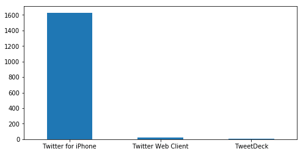

```python
#type of source used
plt.figure(figsize=(8,4))
client = tw_df_clean.source.value_counts()
client.plot(kind='bar',color=sb.color_palette()[0])
plt.xticks(rotation=None);
```

From the above graph, we can see that the most of the user use Iphone to access twitter while the lowest is TweetDeck. There is a drastic difference between them.

## Which breed is found most?

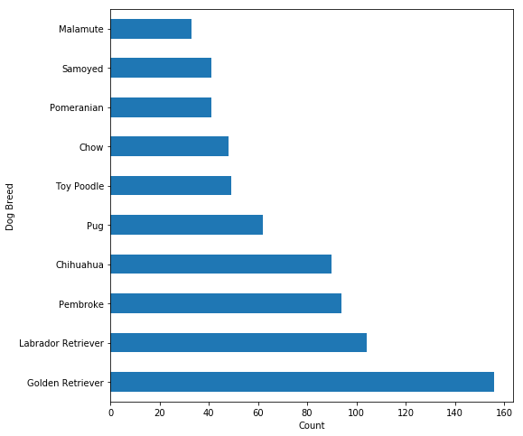

```python
top_breed = tw_df_clean.dog_breed.value_counts().head(10)
plt.figure(figsize=(8,8))
top_breed.plot(kind='barh',color=sb.color_palette()[0])
plt.xlabel('Count');
plt.ylabel('Dog Breed');
```

We can see that the most popular dog breed is Golden Retreiver followed by Labrador Retriever, Pembroke, Chihuahua, Pug and so on. These are the five most popular breed on Twitter and on the internet.

## Which size of dog is found most?

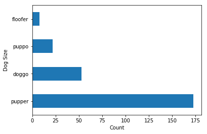

```python
dog_type = tw_df_clean.dog_size.value_counts()[1:]
x = tw_df_clean.dog_size.value_counts().index[1:]
dog_type.plot(kind='barh',color=sb.color_palette()[0])
plt.xlabel('Count');
plt.ylabel('Dog Size');
```

From the graph we can see pupper is found maximum, followed by doggo, puppo and floofer. This means pupper size of dog is found the most.

## Which name is common among dogs?

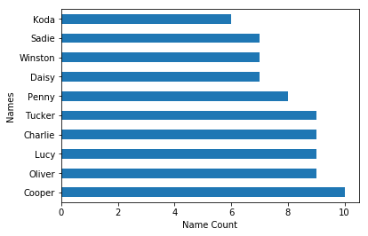

```python
dog_name = tw_df_clean.name.value_counts().head(10)
dog_name.plot(kind='barh',color=sb.color_palette()[0])
plt.xlabel('Name Count');
plt.ylabel('Names');
```

From the above graph, we can say that Cooper is the most used name for dogs followed by Charlie, Oliver, Lucy and Tucker. These are the top 5 most common dog names.

## Conclusion

From the data we can see that the most popular source of accessing twitter is Iphone, this can help twitter to better focus on software development of Iphone to make it efficient to reduce lags. The data about the most retweet and favorited can be used by WeRateDogs admin to determine which is most liked by users so they can provide content of similar type. Moving forward, the most popular dog breed based on image prediction is golden retriever, which means the the page is uploading most photos of golden retriever. The most common dog type is a 'pupper' on this page. The page can try to change the content to see if they see increase in retweet or favorite which can help them increasing their following. Last but not the least, most common name used is Cooper.